# MiniProjet

author : Mlamali SAID SALIMO, Mathieu CISSE, Jonathan LOUAMBA

```r
# load all packages
library(writexl)
library(ggplot2)
library(prettyR)
library(tidyr)
library(corrplot)
library(MASS)
library(leaps)
library(Matrix)
library(glmnet)
library(lmridge)
library(lmtest)
library(caret)
```

# 📦 Le jeu de données

## import et pre process

```r
data_cars = read.csv2("data/CarPrice_Assignment.csv",sep = ",",header = T, dec=".")
data_cars
```

| car_ID | symboling | CarName | fueltype | aspiration | doornumber | carbody | drivewheel | enginelocation | wheelbase | carlength | carwidth | carheight | curbweight | enginetype | cylindernumber | enginesize | fuelsystem | boreratio | stroke | compressionratio | horsepower | peakrpm | citympg | highwaympg | price |
| --- | --- | --- | --- | --- | --- | --- | --- | --- | --- | --- | --- | --- | --- | --- | --- | --- | --- | --- | --- | --- | --- | --- | --- | --- | --- |
| 1 | 3 | alfa-romero giulia | gas | std | two | convertible | rwd | front | 88.6 | 168.8 | 64.1 | 48.8 | 2548 | dohc | four | 130 | mpfi | 3.47 | 2.680 | 9.00 | 111 | 5000 | 21 | 27 | 13495.00 |
| 2 | 3 | alfa-romero stelvio | gas | std | two | convertible | rwd | front | 88.6 | 168.8 | 64.1 | 48.8 | 2548 | dohc | four | 130 | mpfi | 3.47 | 2.680 | 9.00 | 111 | 5000 | 21 | 27 | 16500.00 |
| 3 | 1 | alfa-romero Quadrifoglio | gas | std | two | hatchback | rwd | front | 94.5 | 171.2 | 65.5 | 52.4 | 2823 | ohcv | six | 152 | mpfi | 2.68 | 3.470 | 9.00 | 154 | 5000 | 19 | 26 | 16500.00 |
| 4 | 2 | audi 100 ls | gas | std | four | sedan | fwd | front | 99.8 | 176.6 | 66.2 | 54.3 | 2337 | ohc | four | 109 | mpfi | 3.19 | 3.400 | 10.00 | 102 | 5500 | 24 | 30 | 13950.00 |
| 5 | 2 | audi 100ls | gas | std | four | sedan | 4wd | front | 99.4 | 176.6 | 66.4 | 54.3 | 2824 | ohc | five | 136 | mpfi | 3.19 | 3.400 | 8.00 | 115 | 5500 | 18 | 22 | 17450.00 |
| 6 | 2 | audi fox | gas | std | two | sedan | fwd | front | 99.8 | 177.3 | 66.3 | 53.1 | 2507 | ohc | five | 136 | mpfi | 3.19 | 3.400 | 8.50 | 110 | 5500 | 19 | 25 | 15250.00 |
| 7 | 1 | audi 100ls | gas | std | four | sedan | fwd | front | 105.8 | 192.7 | 71.4 | 55.7 | 2844 | ohc | five | 136 | mpfi | 3.19 | 3.400 | 8.50 | 110 | 5500 | 19 | 25 | 17710.00 |
| 8 | 1 | audi 5000 | gas | std | four | wagon | fwd | front | 105.8 | 192.7 | 71.4 | 55.7 | 2954 | ohc | five | 136 | mpfi | 3.19 | 3.400 | 8.50 | 110 | 5500 | 19 | 25 | 18920.00 |
| 9 | 1 | audi 4000 | gas | turbo | four | sedan | fwd | front | 105.8 | 192.7 | 71.4 | 55.9 | 3086 | ohc | five | 131 | mpfi | 3.13 | 3.400 | 8.30 | 140 | 5500 | 17 | 20 | 23875.00 |
| 10 | 0 | audi 5000s (diesel) | gas | turbo | two | hatchback | 4wd | front | 99.5 | 178.2 | 67.9 | 52.0 | 3053 | ohc | five | 131 | mpfi | 3.13 | 3.400 | 7.00 | 160 | 5500 | 16 | 22 | 17859.17 |

[output cut: 195 more lines]

```r
# sélection des colonnes numériques et lavage
myvars = c("wheelbase","carlength","carwidth","carheight","curbweight","enginesize","boreratio","stroke","compressionratio","horsepower","peakrpm", "citympg",  "highwaympg",   "price")
data_cars = data_cars[myvars]

data_cars # jeu de données initial
```

| wheelbase | carlength | carwidth | carheight | curbweight | enginesize | boreratio | stroke | compressionratio | horsepower | peakrpm | citympg | highwaympg | price |
| --- | --- | --- | --- | --- | --- | --- | --- | --- | --- | --- | --- | --- | --- |
| 88.6 | 168.8 | 64.1 | 48.8 | 2548 | 130 | 3.47 | 2.680 | 9.00 | 111 | 5000 | 21 | 27 | 13495.00 |
| 88.6 | 168.8 | 64.1 | 48.8 | 2548 | 130 | 3.47 | 2.680 | 9.00 | 111 | 5000 | 21 | 27 | 16500.00 |
| 94.5 | 171.2 | 65.5 | 52.4 | 2823 | 152 | 2.68 | 3.470 | 9.00 | 154 | 5000 | 19 | 26 | 16500.00 |
| 99.8 | 176.6 | 66.2 | 54.3 | 2337 | 109 | 3.19 | 3.400 | 10.00 | 102 | 5500 | 24 | 30 | 13950.00 |
| 99.4 | 176.6 | 66.4 | 54.3 | 2824 | 136 | 3.19 | 3.400 | 8.00 | 115 | 5500 | 18 | 22 | 17450.00 |
| 99.8 | 177.3 | 66.3 | 53.1 | 2507 | 136 | 3.19 | 3.400 | 8.50 | 110 | 5500 | 19 | 25 | 15250.00 |
| 105.8 | 192.7 | 71.4 | 55.7 | 2844 | 136 | 3.19 | 3.400 | 8.50 | 110 | 5500 | 19 | 25 | 17710.00 |
| 105.8 | 192.7 | 71.4 | 55.7 | 2954 | 136 | 3.19 | 3.400 | 8.50 | 110 | 5500 | 19 | 25 | 18920.00 |
| 105.8 | 192.7 | 71.4 | 55.9 | 3086 | 131 | 3.13 | 3.400 | 8.30 | 140 | 5500 | 17 | 20 | 23875.00 |
| 99.5 | 178.2 | 67.9 | 52.0 | 3053 | 131 | 3.13 | 3.400 | 7.00 | 160 | 5500 | 16 | 22 | 17859.17 |

[output cut: 195 more lines]

```r
# exporte to excel file
write_xlsx(data_cars,"data_cars initial.xlsx")
```

## 📈 Visualisation du jeu de données

Avant de se lancer dans la construction d’un modèle, il est indispensable de **visualiser les données**. Cela permet d’avoir une idée des **relations entres les variables** et de voir s’il ya des valeurs particulière (points abérrant).

```r
names(data_cars)
```

```
 [1] "wheelbase"        "carlength"        "carwidth"         "carheight"        "curbweight"       "enginesize"
 [7] "boreratio"        "stroke"           "compressionratio" "horsepower"       "peakrpm"          "citympg"
[13] "highwaympg"       "price"
```

```r
print(dim(data_cars))
```

```
[1] 205  14
```

```r
n = nrow(data_cars)
p = ncol(data_cars) - 1
print(c(n,p))
```

```
[1] 205  13
```

```r
str(data_cars)
```

```
'data.frame':   205 obs. of  14 variables:
 $ wheelbase       : num  88.6 88.6 94.5 99.8 99.4 ...
 $ carlength       : num  169 169 171 177 177 ...
 $ carwidth        : num  64.1 64.1 65.5 66.2 66.4 66.3 71.4 71.4 71.4 67.9 ...
 $ carheight       : num  48.8 48.8 52.4 54.3 54.3 53.1 55.7 55.7 55.9 52 ...
 $ curbweight      : int  2548 2548 2823 2337 2824 2507 2844 2954 3086 3053 ...
 $ enginesize      : int  130 130 152 109 136 136 136 136 131 131 ...
 $ boreratio       : num  3.47 3.47 2.68 3.19 3.19 3.19 3.19 3.19 3.13 3.13 ...
 $ stroke          : num  2.68 2.68 3.47 3.4 3.4 3.4 3.4 3.4 3.4 3.4 ...
 $ compressionratio: num  9 9 9 10 8 8.5 8.5 8.5 8.3 7 ...
 $ horsepower      : int  111 111 154 102 115 110 110 110 140 160 ...
 $ peakrpm         : int  5000 5000 5000 5500 5500 5500 5500 5500 5500 5500 ...
 $ citympg         : int  21 21 19 24 18 19 19 19 17 16 ...
 $ highwaympg      : int  27 27 26 30 22 25 25 25 20 22 ...
 $ price           : num  13495 16500 16500 13950 17450 ...
```

```r
describe(data_cars,num.desc = c("mean","median","sd","min","max","valid.n"))
```

```
Description of data_cars

 Numeric
                     mean   median      sd     min      max valid.n
wheelbase           98.76    97.00    6.02   86.60   120.90     205
carlength          174.05   173.20   12.34  141.10   208.10     205
carwidth            65.91    65.50    2.15   60.30    72.30     205
carheight           53.72    54.10    2.44   47.80    59.80     205
curbweight        2555.57  2414.00  520.68 1488.00  4066.00     205
enginesize         126.91   120.00   41.64   61.00   326.00     205
boreratio            3.33     3.31    0.27    2.54     3.94     205
stroke               3.26     3.29    0.31    2.07     4.17     205
compressionratio    10.14     9.00    3.97    7.00    23.00     205
horsepower         104.12    95.00   39.54   48.00   288.00     205
peakrpm           5125.12  5200.00  476.99 4150.00  6600.00     205
citympg             25.22    24.00    6.54   13.00    49.00     205
highwaympg          30.75    30.00    6.89   16.00    54.00     205
price            13276.71 10295.00 7988.85 5118.00 45400.00     205
```

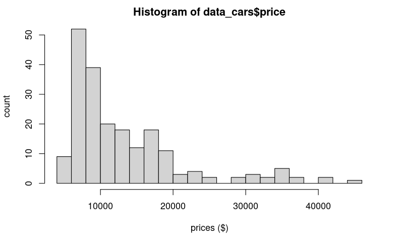

```r
hist(data_cars$price,xlab="prices ($)",ylab="count",breaks=25)
```

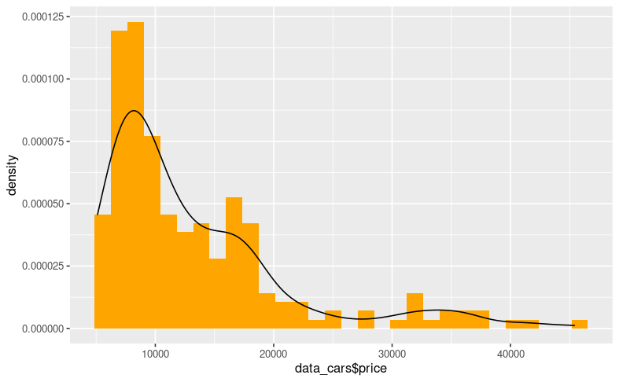

```r
ggplot(data=data_cars, aes(data_cars$price)) +
  geom_histogram(aes(y =..density..), fill = "orange") +
  geom_density()
```

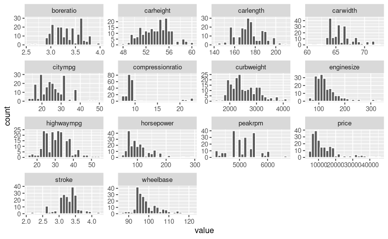

```r
ggplot(gather(gather(data_cars)), aes(value)) +
    geom_histogram(color = "white",bins=25) +
    facet_wrap(~key, scales = "free")
```

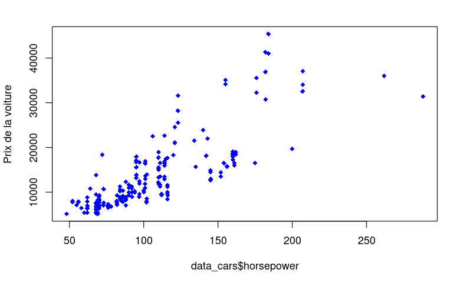

```r
plot(data_cars$horsepower,data_cars$price,pch=18,col="blue", ylab = "Prix de la voiture")
```

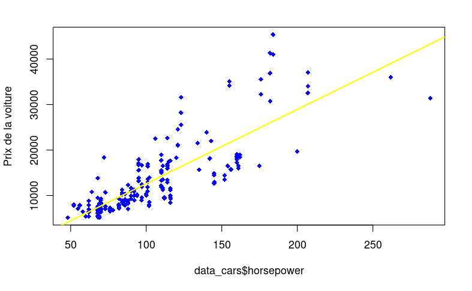

```r
plot(data_cars$horsepower,data_cars$price,pch=18,col="blue", ylab = "Prix de la voiture")
abline( lm(price~horsepower,data=data_cars),lwd=2, col="yellow")
```

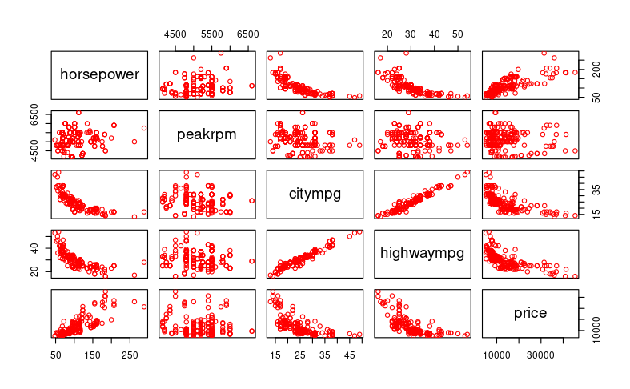

```r
pairs(data_cars[,10:ncol(data_cars)],col="red")
```

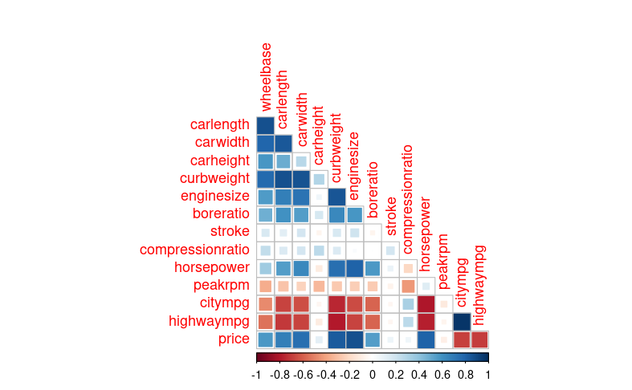

```r
corrplot(cor(data_cars), method = 'square', type = 'lower', diag = FALSE)
```

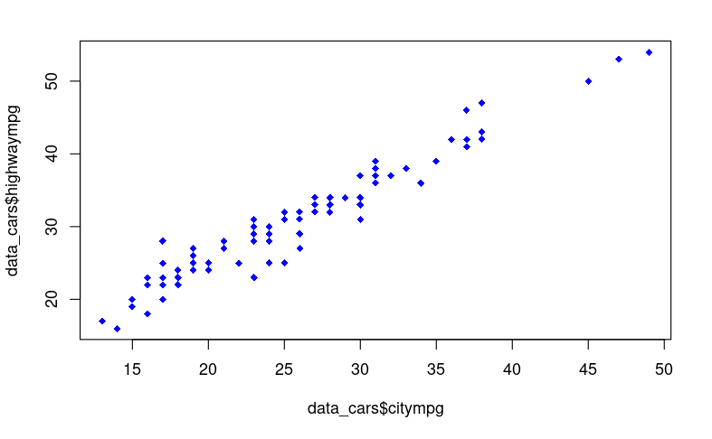

```r
plot(data_cars$citympg,data_cars$highwaympg,pch=18,col="blue")
```

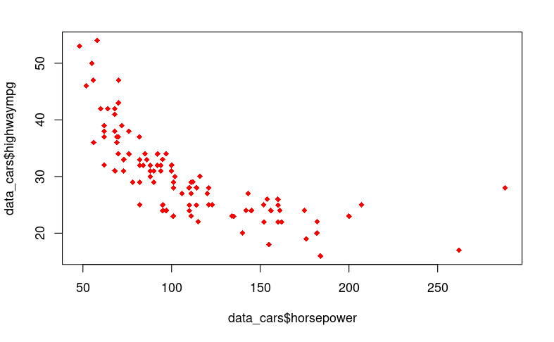

```r
plot(data_cars$horsepower,data_cars$highwaympg,pch=18,col="red")
```

# PARTIE 1 —

## ⚙ (A) Analyse du modèle

### ◼ Décrire votre modèle linéaire

`modele_0` est notre modèle inital : crée à partir de toutes les variables $X_j$ et du dataset initial `data_cars`

```r
modele_0 = lm(price ~., data = data_cars)
summary(modele_0)
```

```
Call:
lm(formula = price ~ ., data = data_cars)

Residuals:
     Min       1Q   Median       3Q      Max
-10789.3  -1671.5   -188.7   1628.8  14243.7

Coefficients:
                   Estimate Std. Error t value Pr(>|t|)
(Intercept)      -4.750e+04  1.527e+04  -3.111 0.002154 **
wheelbase         1.226e+02  1.005e+02   1.220 0.223782
carlength        -9.468e+01  5.556e+01  -1.704 0.089986 .
carwidth          5.056e+02  2.460e+02   2.055 0.041235 *
carheight         1.632e+02  1.357e+02   1.202 0.230727
curbweight        1.885e+00  1.737e+00   1.085 0.279395
enginesize        1.173e+02  1.384e+01   8.481 6.04e-15 ***
boreratio        -1.003e+03  1.196e+03  -0.838 0.402850
stroke           -3.035e+03  7.786e+02  -3.897 0.000134 ***
compressionratio  2.981e+02  8.291e+01   3.596 0.000412 ***
horsepower        3.081e+01  1.622e+01   1.900 0.058959 .
peakrpm           2.375e+00  6.709e-01   3.540 0.000502 ***
citympg          -3.204e+02  1.778e+02  -1.802 0.073110 .
highwaympg        2.028e+02  1.598e+02   1.270 0.205794
---
Signif. codes:  0 ‘***’ 0.001 ‘**’ 0.01 ‘*’ 0.05 ‘.’ 0.1 ‘ ’ 1

Residual standard error: 3189 on 191 degrees of freedom
Multiple R-squared:  0.8508,    Adjusted R-squared:  0.8406
F-statistic: 83.78 on 13 and 191 DF,  p-value: < 2.2e-16
```

```r
modele_0$coefficients
```

```
     (Intercept)        wheelbase        carlength         carwidth        carheight       curbweight       enginesize
   -47495.740595       122.616924       -94.675186       505.571630       163.180142         1.884622       117.346080
       boreratio           stroke compressionratio       horsepower          peakrpm          citympg       highwaympg
    -1002.565423     -3034.606017       298.136931        30.808594         2.375136      -320.354533       202.822067
```

### ◼ La qualité de l’ajustement

La valeur du coefficient de détermination $R²$ de la régression : `Multiple R-squared` = $0.851$. Ce qui veut dire que le prix des voiture est expliqué a $85.1$% par notre premier modèle globale.

*Remarque : c’est bien*

### ◼ Vérification des hypothèses

```r
mean(modele_0$residuals)
```

```
[1] -9.379164e-14
```

*Remarque : espérances des résidues est nulle du point de vue empirique.*

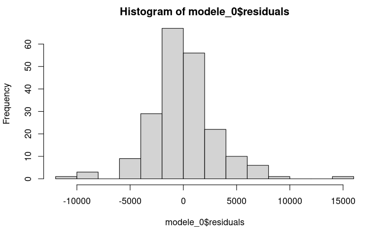

```r
hist(modele_0$residuals)
```

*Remarque : on peut considérer visuellement, graphiquement que les résidus suiventbien une loi normale.*

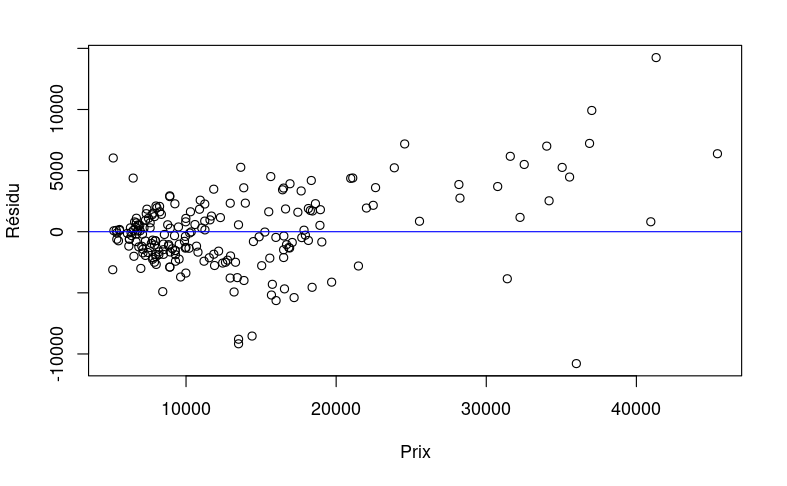

```r
plot(data_cars$price,modele_0$residuals,xlab="Prix",ylab="Résidu")
abline(h=0, col="blue")
```

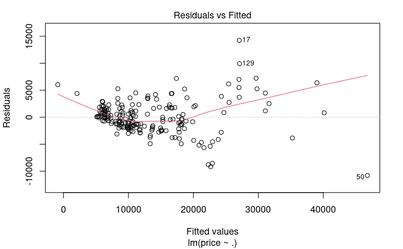

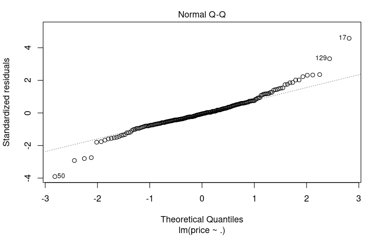

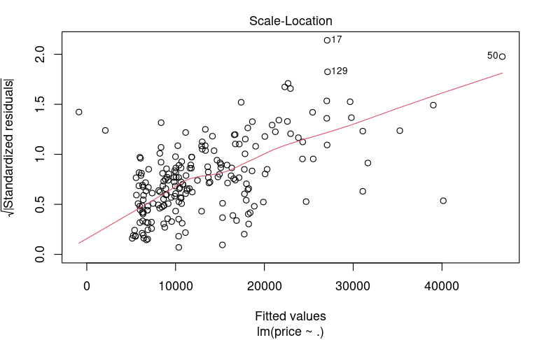

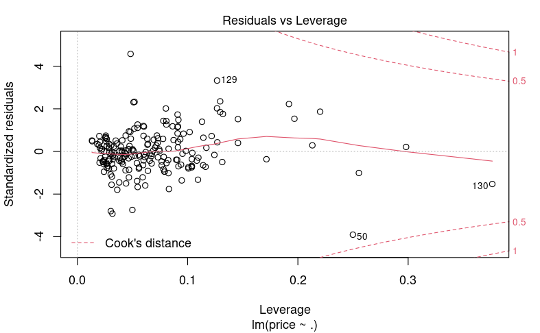

```r
plot(modele_0)
```

```r
dwtest(modele_0)
```

```
    Durbin-Watson test

data:  modele_0
DW = 0.92952, p-value < 2.2e-16
alternative hypothesis: true autocorrelation is greater than 0
```

### ◼ Détection des valeurs atypiques

- **Calcul du Seuil critique**

```r
residus.student = rstudent(modele_0)
```

```r
alpha = 0.1 # on pose un risque alpha de 10%
# calcul du seuil à partir de la loi de Student à (n-p-2) ddl
seuil.student = qt(1-alpha/2,n-p-2)
seuil.student
```

```
[1] 1.652913
```

**🔎 détection des valeurs atypiques au sens de ce seuil :**

```r
atypiques.rstudent = (residus.student < -seuil.student | residus.student > +seuil.student)
ab.student = data_cars[atypiques.rstudent, ]
ab.student # points atypiques/abérrants
```

|  | wheelbase | carlength | carwidth | carheight | curbweight | enginesize | boreratio | stroke | compressionratio | horsepower | peakrpm | citympg | highwaympg | price |
| --- | --- | --- | --- | --- | --- | --- | --- | --- | --- | --- | --- | --- | --- | --- |
| 9 | 105.8 | 192.7 | 71.4 | 55.9 | 3086 | 131 | 3.13 | 3.400 | 8.3 | 140 | 5500 | 17 | 20 | 23875 |
| 15 | 103.5 | 189.0 | 66.9 | 55.7 | 3055 | 164 | 3.31 | 3.190 | 9.0 | 121 | 4250 | 20 | 25 | 24565 |
| 17 | 103.5 | 193.8 | 67.9 | 53.7 | 3380 | 209 | 3.62 | 3.390 | 8.0 | 182 | 5400 | 16 | 22 | 41315 |
| 18 | 110.0 | 197.0 | 70.9 | 56.3 | 3505 | 209 | 3.62 | 3.390 | 8.0 | 182 | 5400 | 15 | 20 | 36880 |
| 19 | 88.4 | 141.1 | 60.3 | 53.2 | 1488 | 61 | 2.91 | 3.030 | 9.5 | 48 | 5100 | 47 | 53 | 5151 |
| 50 | 102.0 | 191.7 | 70.6 | 47.8 | 3950 | 326 | 3.54 | 2.760 | 11.5 | 262 | 5000 | 13 | 17 | 36000 |
| 58 | 95.3 | 169.0 | 65.7 | 49.6 | 2385 | 70 | 3.33 | 3.255 | 9.4 | 101 | 6000 | 17 | 23 | 13645 |
| 71 | 115.6 | 202.6 | 71.7 | 56.3 | 3770 | 183 | 3.58 | 3.640 | 21.5 | 123 | 4350 | 22 | 25 | 31600 |
| 73 | 96.6 | 180.3 | 70.5 | 50.8 | 3685 | 234 | 3.46 | 3.100 | 8.3 | 155 | 4750 | 16 | 18 | 35056 |
| 75 | 112.0 | 199.2 | 72.0 | 55.4 | 3715 | 304 | 3.80 | 3.350 | 8.0 | 184 | 4500 | 14 | 16 | 45400 |

[output cut: 9 more lines]

```r
plot(data_cars$price,residus.student,xlab="Prix",ylab="Résidu studentisées")
abline(h=0)
```

```r
abline(h=-seuil.student,col="green")
abline(h=+seuil.student,col="green")
```

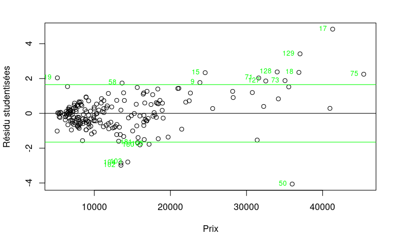

```r
text(ab.student$price,residus.student[atypiques.rstudent],labels=rownames(ab.student), cex= 0.75,pos=2, col = "green") #affiche les point aberrant
```

```r
rownames(ab.student)
```

```
 [1] "9"   "15"  "17"  "18"  "19"  "50"  "58"  "71"  "73"  "75"  "102" "103" "104" "105" "127" "128" "129" "180" "181"
```

- **Calcul du Levier**

```r
# calculez le levier de chaque observation
indicateurs <- influence.measures(modele_0) #Levier
indicateurs
```

```
Influence measures of
     lm(formula = price ~ ., data = data_cars) :
```

|  | dfb.1_ | dfb.whlb | dfb.crln | dfb.crwd | dfb.crhg | dfb.crbw | dfb.engn | dfb.brrt | dfb.strk | dfb.cmpr | dfb.hrsp | dfb.pkrp | dfb.ctym | dfb.hghw | dffit | cov.r | cook.d | hat | inf |
| --- | --- | --- | --- | --- | --- | --- | --- | --- | --- | --- | --- | --- | --- | --- | --- | --- | --- | --- | --- |
| 1 | 3.176242e-02 | -2.492137e-02 | 1.574342e-02 | -9.676715e-03 | -2.342997e-02 | 0.0124312380 | 3.934481e-03 | 1.787773e-03 | -2.530186e-02 | 6.560571e-03 | -1.804912e-02 | -4.615513e-03 | -2.334111e-03 | -2.645195e-03 | 0.0587188875 | 1.1812802 | 2.475306e-04 | 0.09120791 |  |
| 2 | 2.014208e-01 | -1.580384e-01 | 9.983659e-02 | -6.136471e-02 | -1.485807e-01 | 0.0788324676 | 2.495044e-02 | 1.133713e-02 | -1.604513e-01 | 4.160374e-02 | -1.144582e-01 | -2.926919e-02 | -1.480172e-02 | -1.677446e-02 | 0.3723647461 | 1.0700434 | 9.884219e-03 | 0.09120791 |  |
| 3 | -8.791391e-02 | 9.270406e-03 | 5.908550e-03 | 2.917938e-02 | -1.609177e-02 | -0.0193230764 | 2.933620e-02 | 1.601396e-01 | -3.921217e-03 | -1.205659e-02 | -6.630879e-02 | 8.579126e-02 | 4.068798e-02 | -2.432511e-02 | -0.1931506277 | 1.2168180 | 2.675351e-03 | 0.13142704 |  |
| 4 | -3.197052e-02 | 1.734722e-02 | 3.426394e-02 | 1.708148e-02 | 1.083651e-02 | -0.0790692883 | -1.452915e-04 | -2.448056e-02 | 2.552382e-02 | 3.768375e-02 | 3.059786e-02 | 9.747485e-03 | -1.062995e-02 | -9.092302e-03 | 0.1206485447 | 1.0609885 | 1.042177e-03 | 0.02580462 |  |
| 5 | 1.671226e-02 | -1.801346e-02 | -1.795271e-02 | 2.342766e-03 | 2.288074e-02 | 0.0157217434 | 9.731855e-03 | -2.937162e-02 | 1.528552e-02 | 3.484670e-03 | -3.012239e-02 | 1.997173e-02 | 4.509462e-03 | -3.038819e-02 | 0.0964316942 | 1.0940943 | 6.668103e-04 | 0.03480464 |  |
| 6 | -1.689295e-04 | -3.040159e-04 | -1.264705e-04 | -2.908772e-05 | 8.054956e-05 | 0.0009535172 | -7.782232e-04 | 5.007068e-04 | -9.441354e-05 | -6.511299e-04 | 4.090516e-04 | -2.565852e-04 | 6.568604e-04 | -5.401202e-05 | -0.0017625317 | 1.1184371 | 2.230619e-07 | 0.03771738 |  |
| 7 | 4.225098e-02 | 1.684806e-02 | -1.036013e-02 | -4.778532e-02 | -8.737669e-03 | 0.0156604076 | -4.388241e-03 | 1.266735e-02 | -1.282644e-03 | 7.423192e-03 | 1.305800e-02 | -6.962118e-03 | 5.990628e-03 | -3.362305e-03 | -0.0608621248 | 1.2266163 | 2.659416e-04 | 0.12426502 | * |
| 8 | -4.323456e-02 | -1.983647e-02 | 8.213939e-03 | 4.921002e-02 | 8.546202e-03 | -0.0056611700 | 1.017483e-03 | -1.355127e-02 | 1.074455e-03 | -1.235438e-02 | -1.703120e-02 | 9.439516e-03 | -6.544059e-03 | 6.269102e-03 | 0.0629071754 | 1.2161661 | 2.841082e-04 | 0.11698507 |  |
| 9 | -3.520159e-01 | -2.081147e-01 | 1.193998e-01 | 4.567656e-01 | 1.175164e-01 | -0.1000267802 | -2.296138e-01 | -2.421376e-01 | 6.817650e-02 | -1.162349e-01 | 1.387301e-01 | -6.714036e-02 | 2.297029e-01 | -2.534091e-01 | 0.6899582297 | 0.9863307 | 3.362789e-02 | 0.13198691 |  |
| 10 | 1.172681e-03 | 7.677173e-05 | -1.533130e-03 | 1.535489e-03 | -1.250430e-03 | 0.0038426181 | -6.911745e-03 | -5.671008e-03 | 1.000674e-03 | -2.126763e-03 | 4.061285e-03 | -2.802375e-03 | -4.744010e-04 | 5.795654e-04 | 0.0110578697 | 1.1555841 | 8.779927e-06 | 0.06875879 |  |

[output cut: 195 more lines]

```r
attributes(indicateurs)
```

```
$names
[1] "infmat" "is.inf" "call"

$class
[1] "infl"
```

```r
residus.hat = indicateurs$infmat[,"hat"] #on récupère la colonne "hat" qui coreespond au levier # c'est la diagonale
```

**🔎 détection des valeurs atypiques au sens du levier :**

```r
# le seuil est défini par 2(p+1)/n.
seuil.hat = 2*(p+1)/n
seuil.hat
```

```
[1] 0.1365854
```

```r
atypiques.levier = (residus.hat > seuil.hat)
ab.hat = data_cars[atypiques.levier,]
ab.hat # points atypiques/abérrants
```

|  | wheelbase | carlength | carwidth | carheight | curbweight | enginesize | boreratio | stroke | compressionratio | horsepower | peakrpm | citympg | highwaympg | price |
| --- | --- | --- | --- | --- | --- | --- | --- | --- | --- | --- | --- | --- | --- | --- |
| 31 | 86.6 | 144.6 | 63.9 | 50.8 | 1713 | 92 | 2.91 | 3.41 | 9.6 | 58 | 4800 | 49 | 54 | 6479.0 |
| 48 | 113.0 | 199.6 | 69.6 | 52.8 | 4066 | 258 | 3.63 | 4.17 | 8.1 | 176 | 4750 | 15 | 19 | 32250.0 |
| 49 | 113.0 | 199.6 | 69.6 | 52.8 | 4066 | 258 | 3.63 | 4.17 | 8.1 | 176 | 4750 | 15 | 19 | 35550.0 |
| 50 | 102.0 | 191.7 | 70.6 | 47.8 | 3950 | 326 | 3.54 | 2.76 | 11.5 | 262 | 5000 | 13 | 17 | 36000.0 |
| 73 | 96.6 | 180.3 | 70.5 | 50.8 | 3685 | 234 | 3.46 | 3.10 | 8.3 | 155 | 4750 | 16 | 18 | 35056.0 |
| 74 | 120.9 | 208.1 | 71.7 | 56.7 | 3900 | 308 | 3.80 | 3.35 | 8.0 | 184 | 4500 | 14 | 16 | 40960.0 |
| 75 | 112.0 | 199.2 | 72.0 | 55.4 | 3715 | 304 | 3.80 | 3.35 | 8.0 | 184 | 4500 | 14 | 16 | 45400.0 |
| 114 | 114.2 | 198.9 | 68.4 | 56.7 | 3285 | 120 | 3.46 | 2.19 | 8.4 | 95 | 5000 | 19 | 24 | 16695.0 |
| 130 | 98.4 | 175.7 | 72.3 | 50.5 | 3366 | 203 | 3.94 | 3.11 | 10.0 | 288 | 5750 | 17 | 28 | 31400.5 |
| 135 | 99.1 | 186.6 | 66.5 | 56.1 | 2707 | 121 | 2.54 | 2.07 | 9.3 | 110 | 5250 | 21 | 28 | 15040.0 |

[output cut: 1 more lines]

```r
plot(data_cars$price,residus.hat,xlab="Prix",ylab="Levier h_ii")
abline(h=+seuil.hat,col="green")
```

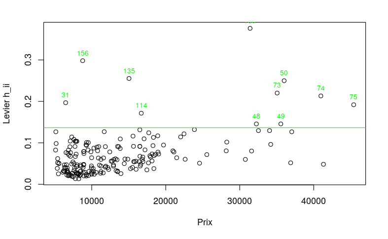

```r
text(ab.hat$price,residus.hat[atypiques.levier],labels=rownames(ab.hat), cex= 0.75,pos=3, col = "green") #affiche les point aberrant
```

```r
rownames(ab.hat)
```

```
 [1] "31"  "48"  "49"  "50"  "73"  "74"  "75"  "114" "130" "135" "156"
```

- **Suppression des valeurs abérrantes**

```r
print(nrow(ab.hat))
```

```
[1] 11
```

```r
print(nrow(ab.student))
```

```
[1] 19
```

```r
union(rownames(ab.hat), rownames(ab.student))
```

```
 [1] "31"  "48"  "49"  "50"  "73"  "74"  "75"  "114" "130" "135" "156" "9"   "15"  "17"  "18"  "19"  "58"  "71"  "102" "103" "104"
[22] "105" "127" "128" "129" "180" "181"
```

```r
idx = intersect( rownames(ab.hat), rownames(ab.student) )
idx
```

```
[1] "50" "73" "75"
```

```r
data_cars[idx ,]
```

|  | wheelbase | carlength | carwidth | carheight | curbweight | enginesize | boreratio | stroke | compressionratio | horsepower | peakrpm | citympg | highwaympg | price |
| --- | --- | --- | --- | --- | --- | --- | --- | --- | --- | --- | --- | --- | --- | --- |
| 50 | 102.0 | 191.7 | 70.6 | 47.8 | 3950 | 326 | 3.54 | 2.76 | 11.5 | 262 | 5000 | 13 | 17 | 36000 |
| 73 | 96.6 | 180.3 | 70.5 | 50.8 | 3685 | 234 | 3.46 | 3.10 | 8.3 | 155 | 4750 | 16 | 18 | 35056 |
| 75 | 112.0 | 199.2 | 72.0 | 55.4 | 3715 | 304 | 3.80 | 3.35 | 8.0 | 184 | 4500 | 14 | 16 | 45400 |

```r
setdiff(rownames(data_cars), idx)
```

```
  [1] "1"   "2"   "3"   "4"   "5"   "6"   "7"   "8"   "9"   "10"  "11"  "12"  "13"  "14"  "15"  "16"  "17"  "18"  "19"  "20"  "21"
 [22] "22"  "23"  "24"  "25"  "26"  "27"  "28"  "29"  "30"  "31"  "32"  "33"  "34"  "35"  "36"  "37"  "38"  "39"  "40"  "41"  "42"
 [43] "43"  "44"  "45"  "46"  "47"  "48"  "49"  "51"  "52"  "53"  "54"  "55"  "56"  "57"  "58"  "59"  "60"  "61"  "62"  "63"  "64"
 [64] "65"  "66"  "67"  "68"  "69"  "70"  "71"  "72"  "74"  "76"  "77"  "78"  "79"  "80"  "81"  "82"  "83"  "84"  "85"  "86"  "87"
 [85] "88"  "89"  "90"  "91"  "92"  "93"  "94"  "95"  "96"  "97"  "98"  "99"  "100" "101" "102" "103" "104" "105" "106" "107" "108"
[106] "109" "110" "111" "112" "113" "114" "115" "116" "117" "118" "119" "120" "121" "122" "123" "124" "125" "126" "127" "128" "129"
[127] "130" "131" "132" "133" "134" "135" "136" "137" "138" "139" "140" "141" "142" "143" "144" "145" "146" "147" "148" "149" "150"
[148] "151" "152" "153" "154" "155" "156" "157" "158" "159" "160" "161" "162" "163" "164" "165" "166" "167" "168" "169" "170" "171"
[169] "172" "173" "174" "175" "176" "177" "178" "179" "180" "181" "182" "183" "184" "185" "186" "187" "188" "189" "190" "191" "192"
[190] "193" "194" "195" "196" "197" "198" "199" "200" "201" "202" "203" "204" "205"
```

```r
data_cars = data_cars[setdiff(rownames(data_cars), idx) ,]
data_cars # nouveau jeu d'apprentissage sans les valeurs abérrantes
```

|  | wheelbase | carlength | carwidth | carheight | curbweight | enginesize | boreratio | stroke | compressionratio | horsepower | peakrpm | citympg | highwaympg | price |
| --- | --- | --- | --- | --- | --- | --- | --- | --- | --- | --- | --- | --- | --- | --- |
| 1 | 88.6 | 168.8 | 64.1 | 48.8 | 2548 | 130 | 3.47 | 2.680 | 9.00 | 111 | 5000 | 21 | 27 | 13495.00 |
| 2 | 88.6 | 168.8 | 64.1 | 48.8 | 2548 | 130 | 3.47 | 2.680 | 9.00 | 111 | 5000 | 21 | 27 | 16500.00 |
| 3 | 94.5 | 171.2 | 65.5 | 52.4 | 2823 | 152 | 2.68 | 3.470 | 9.00 | 154 | 5000 | 19 | 26 | 16500.00 |
| 4 | 99.8 | 176.6 | 66.2 | 54.3 | 2337 | 109 | 3.19 | 3.400 | 10.00 | 102 | 5500 | 24 | 30 | 13950.00 |
| 5 | 99.4 | 176.6 | 66.4 | 54.3 | 2824 | 136 | 3.19 | 3.400 | 8.00 | 115 | 5500 | 18 | 22 | 17450.00 |
| 6 | 99.8 | 177.3 | 66.3 | 53.1 | 2507 | 136 | 3.19 | 3.400 | 8.50 | 110 | 5500 | 19 | 25 | 15250.00 |
| 7 | 105.8 | 192.7 | 71.4 | 55.7 | 2844 | 136 | 3.19 | 3.400 | 8.50 | 110 | 5500 | 19 | 25 | 17710.00 |
| 8 | 105.8 | 192.7 | 71.4 | 55.7 | 2954 | 136 | 3.19 | 3.400 | 8.50 | 110 | 5500 | 19 | 25 | 18920.00 |
| 9 | 105.8 | 192.7 | 71.4 | 55.9 | 3086 | 131 | 3.13 | 3.400 | 8.30 | 140 | 5500 | 17 | 20 | 23875.00 |
| 10 | 99.5 | 178.2 | 67.9 | 52.0 | 3053 | 131 | 3.13 | 3.400 | 7.00 | 160 | 5500 | 16 | 22 | 17859.17 |

[output cut: 192 more lines]

```r
# exporte to excel file
write_xlsx(data_cars,"data_cars.xlsx")
```

`modele` est notre nouveau modèle : crée à partir de toutes les variables $X_j$ et du dataset sans les points atypiques `data_cars`

```r
modele = lm(price ~., data = data_cars)
summary(modele)
```

```
Call:
lm(formula = price ~ ., data = data_cars)

Residuals:
   Min     1Q Median     3Q    Max
 -9296  -1532    -74   1559  13754

Coefficients:
                   Estimate Std. Error t value Pr(>|t|)
(Intercept)      -3.633e+04  1.474e+04  -2.464 0.014635 *
wheelbase         1.715e+02  1.001e+02   1.713 0.088294 .
carlength        -7.149e+01  5.318e+01  -1.344 0.180434
carwidth          3.183e+02  2.446e+02   1.301 0.194754
carheight         6.728e+01  1.310e+02   0.514 0.608196
curbweight        1.488e+00  1.718e+00   0.866 0.387610
enginesize        1.173e+02  1.506e+01   7.788 4.46e-13 ***
boreratio        -1.659e+03  1.159e+03  -1.431 0.153986
stroke           -3.563e+03  7.786e+02  -4.576 8.59e-06 ***
compressionratio  3.484e+02  7.995e+01   4.358 2.16e-05 ***
horsepower        4.431e+01  1.616e+01   2.741 0.006711 **
peakrpm           2.334e+00  6.398e-01   3.648 0.000342 ***
citympg          -3.364e+02  1.708e+02  -1.969 0.050396 .
highwaympg        2.386e+02  1.543e+02   1.546 0.123786
---
Signif. codes:  0 ‘***’ 0.001 ‘**’ 0.01 ‘*’ 0.05 ‘.’ 0.1 ‘ ’ 1

Residual standard error: 3037 on 188 degrees of freedom
Multiple R-squared:  0.8419,    Adjusted R-squared:  0.831
F-statistic: 77.01 on 13 and 188 DF,  p-value: < 2.2e-16
```

## ⚙ (B) Étude de la significativité de chaque variable dans votre modèle.

```r
summary(modele)
```

```
Call:
lm(formula = price ~ ., data = data_cars)

Residuals:
   Min     1Q Median     3Q    Max
 -9296  -1532    -74   1559  13754

Coefficients:
                   Estimate Std. Error t value Pr(>|t|)
(Intercept)      -3.633e+04  1.474e+04  -2.464 0.014635 *
wheelbase         1.715e+02  1.001e+02   1.713 0.088294 .
carlength        -7.149e+01  5.318e+01  -1.344 0.180434
carwidth          3.183e+02  2.446e+02   1.301 0.194754
carheight         6.728e+01  1.310e+02   0.514 0.608196
curbweight        1.488e+00  1.718e+00   0.866 0.387610
enginesize        1.173e+02  1.506e+01   7.788 4.46e-13 ***
boreratio        -1.659e+03  1.159e+03  -1.431 0.153986
stroke           -3.563e+03  7.786e+02  -4.576 8.59e-06 ***
compressionratio  3.484e+02  7.995e+01   4.358 2.16e-05 ***
horsepower        4.431e+01  1.616e+01   2.741 0.006711 **
peakrpm           2.334e+00  6.398e-01   3.648 0.000342 ***
citympg          -3.364e+02  1.708e+02  -1.969 0.050396 .
highwaympg        2.386e+02  1.543e+02   1.546 0.123786
---
Signif. codes:  0 ‘***’ 0.001 ‘**’ 0.01 ‘*’ 0.05 ‘.’ 0.1 ‘ ’ 1

Residual standard error: 3037 on 188 degrees of freedom
Multiple R-squared:  0.8419,    Adjusted R-squared:  0.831
F-statistic: 77.01 on 13 and 188 DF,  p-value: < 2.2e-16
```

## ⚙ (C) Étudier la significativité globale du modèle.

```r
summary(modele)
```

```
Call:
lm(formula = price ~ ., data = data_cars)

Residuals:
   Min     1Q Median     3Q    Max
 -9296  -1532    -74   1559  13754

Coefficients:
                   Estimate Std. Error t value Pr(>|t|)
(Intercept)      -3.633e+04  1.474e+04  -2.464 0.014635 *
wheelbase         1.715e+02  1.001e+02   1.713 0.088294 .
carlength        -7.149e+01  5.318e+01  -1.344 0.180434
carwidth          3.183e+02  2.446e+02   1.301 0.194754
carheight         6.728e+01  1.310e+02   0.514 0.608196
curbweight        1.488e+00  1.718e+00   0.866 0.387610
enginesize        1.173e+02  1.506e+01   7.788 4.46e-13 ***
boreratio        -1.659e+03  1.159e+03  -1.431 0.153986
stroke           -3.563e+03  7.786e+02  -4.576 8.59e-06 ***
compressionratio  3.484e+02  7.995e+01   4.358 2.16e-05 ***
horsepower        4.431e+01  1.616e+01   2.741 0.006711 **
peakrpm           2.334e+00  6.398e-01   3.648 0.000342 ***
citympg          -3.364e+02  1.708e+02  -1.969 0.050396 .
highwaympg        2.386e+02  1.543e+02   1.546 0.123786
---
Signif. codes:  0 ‘***’ 0.001 ‘**’ 0.01 ‘*’ 0.05 ‘.’ 0.1 ‘ ’ 1

Residual standard error: 3037 on 188 degrees of freedom
Multiple R-squared:  0.8419,    Adjusted R-squared:  0.831
F-statistic: 77.01 on 13 and 188 DF,  p-value: < 2.2e-16
```

On utilise le test de Fisher pour étudier la significativité globale. En effet, on regarde `F-statistic` pour valider le modèle defaçon globale.

`p-value` < 2.2 e-16 < 5% donc on rejète H_0 (a1=a2=a3 =… = 0)

La p-valeur < 0.005 donc l’utilisation du modèle linéaire multiple est pertinente. Les variables sont globalement ignificatives

## ⚙ (D)

### ◼ Etude de l’éventuelle colinéarité entre les variables du modèle

Heatmap to better understand correlation

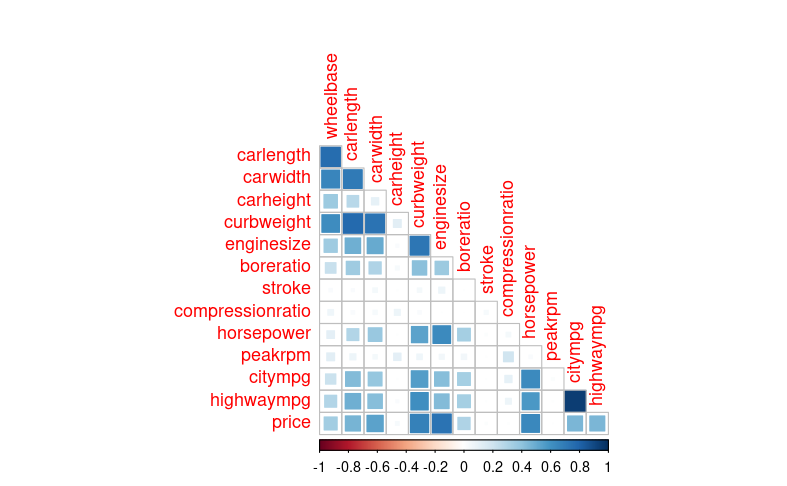

```r
M_cor_squared = cor(data_cars)^2
corrplot(M_cor_squared, method = 'square', type = 'lower', diag = FALSE)
```

```r
R_carre = summary(modele)$r.squared
R_carre
```

```
[1] 0.8419045
```

```r
rownames(M_cor_squared)
```

```
 [1] "wheelbase"        "carlength"        "carwidth"         "carheight"        "curbweight"       "enginesize"
 [7] "boreratio"        "stroke"           "compressionratio" "horsepower"       "peakrpm"          "citympg"
[13] "highwaympg"       "price"
```

```r
listes_var = rownames(M_cor_squared)
for (i in 1:ncol(M_cor_squared)) {
  for (j in 1:ncol(M_cor_squared)) {

    if(M_cor_squared[i,j] > R_carre  && i != j) {
      print(c(listes_var[i],listes_var[j],M_cor_squared[i,j]))
    }
  }
}
```

```
[1] "citympg"           "highwaympg"        "0.942605072306204"
[1] "highwaympg"        "citympg"           "0.942605072306204"
```

*Remarque : on peut déjà soupconner les var ‘citympg’ et ‘highwaympg’ d’être colinéaire*

### ◼ Sélection de variables (en précisant les critères utilisés)

Trier les coefficients selon les valeurs de p-value

```r
pValues = summary(modele)$coef[,4]
sort(pValues)
```

```
      enginesize           stroke compressionratio          peakrpm       horsepower      (Intercept)          citympg
    4.457447e-13     8.588348e-06     2.159865e-05     3.424870e-04     6.711169e-03     1.463495e-02     5.039597e-02
       wheelbase       highwaympg        boreratio        carlength         carwidth       curbweight        carheight
    8.829442e-02     1.237855e-01     1.539862e-01     1.804339e-01     1.947543e-01     3.876104e-01     6.081959e-01
```

*Remarque : enginesize est le plus petit p-value, il est + significatif par rapport à curbweight carlength …*

Pour pouvoir choisir un sous-ensemble nous allons appliquer plusieurs types de **méthode de stepwise**.

Pour utiliser la commande `step` on doit spécifier le modèle de départ `m0` et le modèle maximal `mf` qui peut être le modèle complet.

```r
m0 = lm(price~1,data=data_cars)  # choix du modèle avec constante seulement
mf = modele
```

#### La sélection **ascendante** utilisant le critère AIC

```r
modele_step_forward = step(m0, scope=list(lower=m0, upper=mf),data=data_cars, direction="forward")
```

```
Start:  AIC=3599.62
price ~ 1

                   Df  Sum of Sq        RSS    AIC
+ enginesize        1 8037533989 2.9304e+09 3335.0
+ curbweight        1 7436772261 3.5312e+09 3372.7
+ horsepower        1 7021542547 3.9464e+09 3395.1
+ carwidth          1 5886151413 5.0818e+09 3446.2
+ carlength         1 5088934795 5.8790e+09 3475.7
+ highwaympg        1 5007957453 5.9600e+09 3478.4
+ citympg           1 4988682977 5.9793e+09 3479.1
+ wheelbase         1 3771306513 7.1967e+09 3516.5
+ boreratio         1 3331571485 7.6364e+09 3528.5
+ carheight         1  330801050 1.0637e+10 3595.4
+ stroke            1  138888515 1.0829e+10 3599.0
<none>                           1.0968e+10 3599.6
+ compressionratio  1   84007903 1.0884e+10 3600.1
+ peakrpm           1   26349828 1.0942e+10 3601.1

Step:  AIC=3335.01
price ~ enginesize

                   Df Sum of Sq        RSS    AIC
+ horsepower        1 428523852 2501923518 3305.1
+ curbweight        1 357185969 2573261400 3310.8
+ carwidth          1 330861876 2599585493 3312.8
+ citympg           1 268286504 2662160866 3317.6
+ peakrpm           1 256164544 2674282826 3318.5
+ highwaympg        1 231901679 2698545691 3320.4
+ stroke            1 185183426 2745263944 3323.8
+ carlength         1 150452928 2779994442 3326.4
+ wheelbase         1  97122350 2833325019 3330.2
<none>                          2930447370 3335.0
+ compressionratio  1  27471182 2902976188 3335.1
+ carheight         1  26036378 2904410992 3335.2
+ boreratio         1  20356699 2910090671 3335.6

Step:  AIC=3305.08
price ~ enginesize + horsepower

```

[output cut: 70 more lines]

```
+ boreratio   1  10458119 1826240577 3251.5
+ carlength   1   6469485 1830229212 3251.9

Step:  AIC=3248.72
price ~ enginesize + horsepower + carwidth + stroke + compressionratio +
    peakrpm + wheelbase

             Df Sum of Sq        RSS    AIC
<none>                    1801441070 3248.7
+ boreratio   1  15854569 1785586501 3248.9
+ citympg     1  10954808 1790486263 3249.5
+ curbweight  1   6072557 1795368513 3250.0
+ highwaympg  1   2330324 1799110746 3250.5
+ carlength   1   2057417 1799383654 3250.5
+ carheight   1   1054152 1800386918 3250.6
```

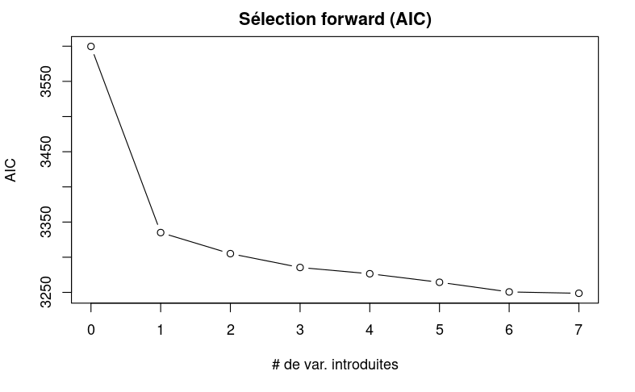

```r
plot(0:(nrow(modele_step_forward$anova)-1),modele_step_forward$anova[,"AIC"],type="b",xlab="# de var. introduites",ylab="AIC",main="Sélection forward (AIC)")
```

```r
summary(modele_step_forward)
```

```
Call:
lm(formula = price ~ enginesize + horsepower + carwidth + stroke +
    compressionratio + peakrpm + wheelbase, data = data_cars)

Residuals:
    Min      1Q  Median      3Q     Max
-8819.7 -1630.0  -170.9  1574.4 13462.8

Coefficients:
                   Estimate Std. Error t value Pr(>|t|)
(Intercept)      -4.742e+04  1.101e+04  -4.306 2.63e-05 ***
enginesize        1.152e+02  1.395e+01   8.258 2.26e-14 ***
horsepower        5.481e+01  1.337e+01   4.099 6.09e-05 ***
carwidth          3.266e+02  2.302e+02   1.419   0.1575
stroke           -3.259e+03  7.435e+02  -4.383 1.91e-05 ***
compressionratio  3.217e+02  6.511e+01   4.940 1.68e-06 ***
peakrpm           2.499e+00  6.062e-01   4.122 5.55e-05 ***
wheelbase         1.356e+02  6.957e+01   1.949   0.0528 .
---
Signif. codes:  0 ‘***’ 0.001 ‘**’ 0.01 ‘*’ 0.05 ‘.’ 0.1 ‘ ’ 1

Residual standard error: 3047 on 194 degrees of freedom
Multiple R-squared:  0.8358,    Adjusted R-squared:  0.8298
F-statistic:   141 on 7 and 194 DF,  p-value: < 2.2e-16
```

#### La sélection **descendante** utilisant le critère AIC

```r
modele_step_backward = step(mf,data=data_cars,direction="backward")
```

```
Start:  AIC=3253.02
price ~ wheelbase + carlength + carwidth + carheight + curbweight +
    enginesize + boreratio + stroke + compressionratio + horsepower +
    peakrpm + citympg + highwaympg

                   Df Sum of Sq        RSS    AIC
- carheight         1   2432149 1736420600 3251.3
- curbweight        1   6916622 1740905072 3251.8
- carwidth          1  15618215 1749606666 3252.8
- carlength         1  16670769 1750659220 3252.9
<none>                          1733988451 3253.0
- boreratio         1  18896806 1752885257 3253.2
- highwaympg        1  22044940 1756033391 3253.6
- wheelbase         1  27076123 1761064574 3254.1
- citympg           1  35766881 1769755332 3255.1
- horsepower        1  69308706 1803297157 3258.9
- peakrpm           1 122727437 1856715888 3264.8
- compressionratio  1 175146883 1909135334 3270.5
- stroke            1 193144021 1927132471 3272.3
- enginesize        1 559411136 2293399587 3307.5

Step:  AIC=3251.3
price ~ wheelbase + carlength + carwidth + curbweight + enginesize +
    boreratio + stroke + compressionratio + horsepower + peakrpm +
    citympg + highwaympg

                   Df Sum of Sq        RSS    AIC
- curbweight        1   7490229 1743910829 3250.2
- carwidth          1  13660579 1750081179 3250.9
- carlength         1  14517447 1750938047 3251.0
<none>                          1736420600 3251.3
- boreratio         1  19759344 1756179944 3251.6
- highwaympg        1  22138147 1758558746 3251.9
- citympg           1  34882350 1771302950 3253.3
- wheelbase         1  35346965 1771767565 3253.4
- horsepower        1  68397434 1804818033 3257.1
- peakrpm           1 121616944 1858037543 3263.0
- compressionratio  1 175846788 1912267388 3268.8
- stroke            1 208078141 1944498740 3272.2
- enginesize        1 558234891 2294655491 3305.6
```

[output cut: 52 more lines]

```

Step:  AIC=3248.64
price ~ wheelbase + enginesize + boreratio + stroke + compressionratio +
    horsepower + peakrpm + citympg

                   Df Sum of Sq        RSS    AIC
<none>                          1782990913 3248.6
- boreratio         1  21831925 1804822838 3249.1
- citympg           1  22656643 1805647556 3249.2
- wheelbase         1 106178251 1889169164 3258.3
- peakrpm           1 116532688 1899523600 3259.4
- horsepower        1 136012962 1919003874 3261.5
- stroke            1 189251238 1972242151 3267.0
- compressionratio  1 286423636 2069414549 3276.7
- enginesize        1 650938303 2433929216 3309.5
```

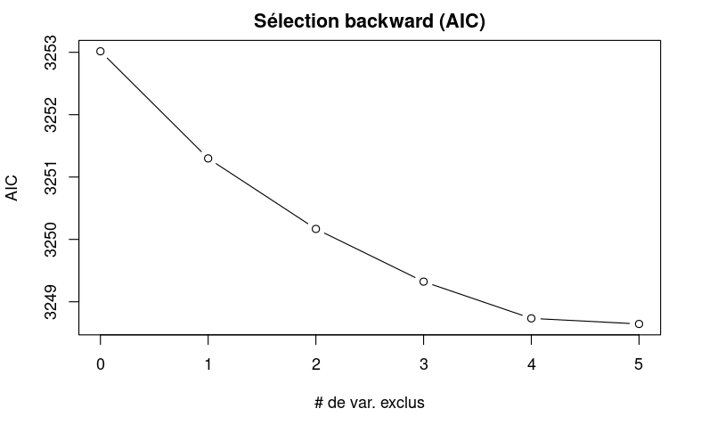

```r
plot(0:(nrow(modele_step_backward$anova)-1),modele_step_backward$anova[,"AIC"],type="b",xlab="# de var. exclus",ylab="AIC",main="Sélection backward (AIC)")
```

```r
summary(modele_step_backward)
```

```
Call:
lm(formula = price ~ wheelbase + enginesize + boreratio + stroke +
    compressionratio + horsepower + peakrpm + citympg, data = data_cars)

Residuals:
    Min      1Q  Median      3Q     Max
-9498.6 -1510.1   -93.7  1522.2 13345.6

Coefficients:
                   Estimate Std. Error t value Pr(>|t|)
(Intercept)      -2.126e+04  8.787e+03  -2.419 0.016475 *
wheelbase         1.836e+02  5.415e+01   3.390 0.000847 ***
enginesize        1.174e+02  1.399e+01   8.394 9.91e-15 ***
boreratio        -1.769e+03  1.151e+03  -1.537 0.125865
stroke           -3.440e+03  7.601e+02  -4.526 1.05e-05 ***
compressionratio  3.846e+02  6.907e+01   5.568 8.55e-08 ***
horsepower        5.658e+01  1.475e+01   3.837 0.000169 ***
peakrpm           2.233e+00  6.287e-01   3.552 0.000481 ***
citympg          -1.048e+02  6.691e+01  -1.566 0.118978
---
Signif. codes:  0 ‘***’ 0.001 ‘**’ 0.01 ‘*’ 0.05 ‘.’ 0.1 ‘ ’ 1

Residual standard error: 3039 on 193 degrees of freedom
Multiple R-squared:  0.8374,    Adjusted R-squared:  0.8307
F-statistic: 124.3 on 8 and 193 DF,  p-value: < 2.2e-16
```

#### La sélection ascendante avec le **F−test**.

```r
modele_step_forward_Ftest = step(m0, scope=list(lower=m0, upper=mf),data=data_cars, direction="forward",test="F")
```

```
Start:  AIC=3599.62
price ~ 1

                   Df  Sum of Sq        RSS    AIC  F value  Pr(>F)
+ enginesize        1 8037533989 2.9304e+09 3335.0 548.5534 < 2e-16 ***
+ curbweight        1 7436772261 3.5312e+09 3372.7 421.2026 < 2e-16 ***
+ horsepower        1 7021542547 3.9464e+09 3395.1 355.8420 < 2e-16 ***
+ carwidth          1 5886151413 5.0818e+09 3446.2 231.6548 < 2e-16 ***
+ carlength         1 5088934795 5.8790e+09 3475.7 173.1211 < 2e-16 ***
+ highwaympg        1 5007957453 5.9600e+09 3478.4 168.0516 < 2e-16 ***
+ citympg           1 4988682977 5.9793e+09 3479.1 166.8652 < 2e-16 ***
+ wheelbase         1 3771306513 7.1967e+09 3516.5 104.8069 < 2e-16 ***
+ boreratio         1 3331571485 7.6364e+09 3528.5  87.2549 < 2e-16 ***
+ carheight         1  330801050 1.0637e+10 3595.4   6.2197 0.01344 *
+ stroke            1  138888515 1.0829e+10 3599.0   2.5651 0.11082
<none>                           1.0968e+10 3599.6
+ compressionratio  1   84007903 1.0884e+10 3600.1   1.5437 0.21552
+ peakrpm           1   26349828 1.0942e+10 3601.1   0.4816 0.48848
---
Signif. codes:  0 ‘***’ 0.001 ‘**’ 0.01 ‘*’ 0.05 ‘.’ 0.1 ‘ ’ 1

Step:  AIC=3335.01
price ~ enginesize

                   Df Sum of Sq        RSS    AIC F value    Pr(>F)
+ horsepower        1 428523852 2501923518 3305.1 34.0843 2.118e-08 ***
+ curbweight        1 357185969 2573261400 3310.8 27.6225 3.783e-07 ***
+ carwidth          1 330861876 2599585493 3312.8 25.3277 1.079e-06 ***
+ citympg           1 268286504 2662160866 3317.6 20.0548 1.267e-05 ***
+ peakrpm           1 256164544 2674282826 3318.5 19.0618 2.033e-05 ***
+ highwaympg        1 231901679 2698545691 3320.4 17.1012 5.224e-05 ***
+ stroke            1 185183426 2745263944 3323.8 13.4237 0.0003186 ***
+ carlength         1 150452928 2779994442 3326.4 10.7699 0.0012183 **
+ wheelbase         1  97122350 2833325019 3330.2  6.8214 0.0096937 **
<none>                          2930447370 3335.0
+ compressionratio  1  27471182 2902976188 3335.1  1.8832 0.1715204
+ carheight         1  26036378 2904410992 3335.2  1.7839 0.1831942
+ boreratio         1  20356699 2910090671 3335.6  1.3920 0.2394682
---
Signif. codes:  0 ‘***’ 0.001 ‘**’ 0.01 ‘*’ 0.05 ‘.’ 0.1 ‘ ’ 1
```

[output cut: 84 more lines]

```
---
Signif. codes:  0 ‘***’ 0.001 ‘**’ 0.01 ‘*’ 0.05 ‘.’ 0.1 ‘ ’ 1

Step:  AIC=3248.72
price ~ enginesize + horsepower + carwidth + stroke + compressionratio +
    peakrpm + wheelbase

             Df Sum of Sq        RSS    AIC F value Pr(>F)
<none>                    1801441070 3248.7
+ boreratio   1  15854569 1785586501 3248.9  1.7137 0.1921
+ citympg     1  10954808 1790486263 3249.5  1.1808 0.2785
+ curbweight  1   6072557 1795368513 3250.0  0.6528 0.4201
+ highwaympg  1   2330324 1799110746 3250.5  0.2500 0.6177
+ carlength   1   2057417 1799383654 3250.5  0.2207 0.6391
+ carheight   1   1054152 1800386918 3250.6  0.1130 0.7371
```

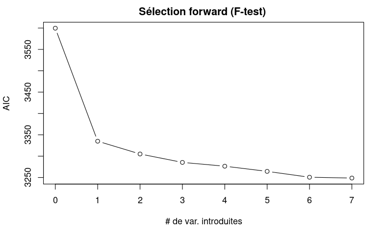

```r
plot(0:(nrow(modele_step_forward_Ftest$anova)-1),modele_step_forward_Ftest$anova[,"AIC"],type="b",xlab="# de var. introduites",ylab="AIC",main="Sélection forward (F-test) ")
```

```r
summary(modele_step_forward_Ftest)
```

```
Call:
lm(formula = price ~ enginesize + horsepower + carwidth + stroke +
    compressionratio + peakrpm + wheelbase, data = data_cars)

Residuals:
    Min      1Q  Median      3Q     Max
-8819.7 -1630.0  -170.9  1574.4 13462.8

Coefficients:
                   Estimate Std. Error t value Pr(>|t|)
(Intercept)      -4.742e+04  1.101e+04  -4.306 2.63e-05 ***
enginesize        1.152e+02  1.395e+01   8.258 2.26e-14 ***
horsepower        5.481e+01  1.337e+01   4.099 6.09e-05 ***
carwidth          3.266e+02  2.302e+02   1.419   0.1575
stroke           -3.259e+03  7.435e+02  -4.383 1.91e-05 ***
compressionratio  3.217e+02  6.511e+01   4.940 1.68e-06 ***
peakrpm           2.499e+00  6.062e-01   4.122 5.55e-05 ***
wheelbase         1.356e+02  6.957e+01   1.949   0.0528 .
---
Signif. codes:  0 ‘***’ 0.001 ‘**’ 0.01 ‘*’ 0.05 ‘.’ 0.1 ‘ ’ 1

Residual standard error: 3047 on 194 degrees of freedom
Multiple R-squared:  0.8358,    Adjusted R-squared:  0.8298
F-statistic:   141 on 7 and 194 DF,  p-value: < 2.2e-16
```

#### La sélection descendante avec le **F−test**.

```r
modele_step_backward_Ftest = step(mf,data=data_cars,direction="backward",test="F")
```

```
Start:  AIC=3253.02
price ~ wheelbase + carlength + carwidth + carheight + curbweight +
    enginesize + boreratio + stroke + compressionratio + horsepower +
    peakrpm + citympg + highwaympg

                   Df Sum of Sq        RSS    AIC F value    Pr(>F)
- carheight         1   2432149 1736420600 3251.3  0.2637 0.6081959
- curbweight        1   6916622 1740905072 3251.8  0.7499 0.3876104
- carwidth          1  15618215 1749606666 3252.8  1.6933 0.1947543
- carlength         1  16670769 1750659220 3252.9  1.8075 0.1804339
<none>                          1733988451 3253.0
- boreratio         1  18896806 1752885257 3253.2  2.0488 0.1539862
- highwaympg        1  22044940 1756033391 3253.6  2.3901 0.1237855
- wheelbase         1  27076123 1761064574 3254.1  2.9356 0.0882944 .
- citympg           1  35766881 1769755332 3255.1  3.8779 0.0503960 .
- horsepower        1  69308706 1803297157 3258.9  7.5145 0.0067112 **
- peakrpm           1 122727437 1856715888 3264.8 13.3062 0.0003425 ***
- compressionratio  1 175146883 1909135334 3270.5 18.9895 2.160e-05 ***
- stroke            1 193144021 1927132471 3272.3 20.9408 8.588e-06 ***
- enginesize        1 559411136 2293399587 3307.5 60.6517 4.457e-13 ***
---
Signif. codes:  0 ‘***’ 0.001 ‘**’ 0.01 ‘*’ 0.05 ‘.’ 0.1 ‘ ’ 1

Step:  AIC=3251.3
price ~ wheelbase + carlength + carwidth + curbweight + enginesize +
    boreratio + stroke + compressionratio + horsepower + peakrpm +
    citympg + highwaympg

                   Df Sum of Sq        RSS    AIC F value    Pr(>F)
- curbweight        1   7490229 1743910829 3250.2  0.8153  0.367716
- carwidth          1  13660579 1750081179 3250.9  1.4869  0.224221
- carlength         1  14517447 1750938047 3251.0  1.5801  0.210291
<none>                          1736420600 3251.3
- boreratio         1  19759344 1756179944 3251.6  2.1507  0.144167
- highwaympg        1  22138147 1758558746 3251.9  2.4096  0.122265
- citympg           1  34882350 1771302950 3253.3  3.7968  0.052833 .
- wheelbase         1  35346965 1771767565 3253.4  3.8473  0.051294 .
- horsepower        1  68397434 1804818033 3257.1  7.4447  0.006963 **
- peakrpm           1 121616944 1858037543 3263.0 13.2373  0.000354 ***
- compressionratio  1 175846788 1912267388 3268.8 19.1400 2.006e-05 ***
```

[output cut: 64 more lines]

```
price ~ wheelbase + enginesize + boreratio + stroke + compressionratio +
    horsepower + peakrpm + citympg

                   Df Sum of Sq        RSS    AIC F value    Pr(>F)
<none>                          1782990913 3248.6
- boreratio         1  21831925 1804822838 3249.1  2.3632 0.1258650
- citympg           1  22656643 1805647556 3249.2  2.4525 0.1189782
- wheelbase         1 106178251 1889169164 3258.3 11.4933 0.0008470 ***
- peakrpm           1 116532688 1899523600 3259.4 12.6141 0.0004811 ***
- horsepower        1 136012962 1919003874 3261.5 14.7227 0.0001686 ***
- stroke            1 189251238 1972242151 3267.0 20.4855 1.049e-05 ***
- compressionratio  1 286423636 2069414549 3276.7 31.0040 8.545e-08 ***
- enginesize        1 650938303 2433929216 3309.5 70.4609 9.914e-15 ***
---
Signif. codes:  0 ‘***’ 0.001 ‘**’ 0.01 ‘*’ 0.05 ‘.’ 0.1 ‘ ’ 1
```

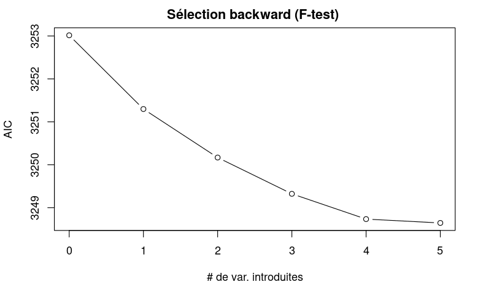

```r
plot(0:(nrow(modele_step_backward_Ftest$anova)-1),modele_step_backward_Ftest$anova[,"AIC"],type="b",xlab="# de var. introduites",ylab="AIC",main="Sélection backward (F-test) ")
```

```r
summary(modele_step_backward_Ftest)
```

```
Call:
lm(formula = price ~ wheelbase + enginesize + boreratio + stroke +
    compressionratio + horsepower + peakrpm + citympg, data = data_cars)

Residuals:
    Min      1Q  Median      3Q     Max
-9498.6 -1510.1   -93.7  1522.2 13345.6

Coefficients:
                   Estimate Std. Error t value Pr(>|t|)
(Intercept)      -2.126e+04  8.787e+03  -2.419 0.016475 *
wheelbase         1.836e+02  5.415e+01   3.390 0.000847 ***
enginesize        1.174e+02  1.399e+01   8.394 9.91e-15 ***
boreratio        -1.769e+03  1.151e+03  -1.537 0.125865
stroke           -3.440e+03  7.601e+02  -4.526 1.05e-05 ***
compressionratio  3.846e+02  6.907e+01   5.568 8.55e-08 ***
horsepower        5.658e+01  1.475e+01   3.837 0.000169 ***
peakrpm           2.233e+00  6.287e-01   3.552 0.000481 ***
citympg          -1.048e+02  6.691e+01  -1.566 0.118978
---
Signif. codes:  0 ‘***’ 0.001 ‘**’ 0.01 ‘*’ 0.05 ‘.’ 0.1 ‘ ’ 1

Residual standard error: 3039 on 193 degrees of freedom
Multiple R-squared:  0.8374,    Adjusted R-squared:  0.8307
F-statistic: 124.3 on 8 and 193 DF,  p-value: < 2.2e-16
```

```r
print(formula(modele_step_backward))
```

```
price ~ wheelbase + enginesize + boreratio + stroke + compressionratio +
    horsepower + peakrpm + citympg
```

```r
print(formula(modele_step_backward_Ftest))
```

```
price ~ wheelbase + enginesize + boreratio + stroke + compressionratio +
    horsepower + peakrpm + citympg
```

```r
print(formula(modele_step_forward))
```

```
price ~ enginesize + horsepower + carwidth + stroke + compressionratio +
    peakrpm + wheelbase
```

```r
print(formula(modele_step_forward_Ftest))
```

```
price ~ enginesize + horsepower + carwidth + stroke + compressionratio +
    peakrpm + wheelbase
```

_Remarque : Pour une même méthode (acsendante ou descendante), on voit que les variables sélectionné sont les mêmes, avec ou sans le critère de Fisher. De plus, on remarque que pour une même méthode, sur le graphique AIC de la methode avec le F-Test et celle sans, sont équivalent : il se passe la même chose, c’est la même chose.

Les deux modèles sont équivalents.

Nous qui pensions obtenir 4 modèle différents, on en obtiens seulement 2. Donc pour la suite, on ne s’interresse seulement qu’à `modele_step_forward` et `modele_step_backward`. _

## ⚙ (E) Validation croisée

### ◼ La procédure Hold Out

#### Split : Train - Test

```r
set.seed(123) #pour garder le même découpage

n = nrow(data_cars)
c=runif(n)
rang=rank(c) #associer à chaque individu un numéro de rang dans c

train_size = (3*n)%/%4 # taille de l'ensemble d'apprentissage en arrondi
train_index = rang[1:train_size] #définir les individus de l'ensemble d'apprentissage
train_size
```

```
[1] 151
```

```r
train.data = data_cars[train_index,] # train set
train.data
```

|  | wheelbase | carlength | carwidth | carheight | curbweight | enginesize | boreratio | stroke | compressionratio | horsepower | peakrpm | citympg | highwaympg | price |
| --- | --- | --- | --- | --- | --- | --- | --- | --- | --- | --- | --- | --- | --- | --- |
| 55 | 93.1 | 166.8 | 64.2 | 54.1 | 1950 | 91 | 3.08 | 3.150 | 9.00 | 68 | 5000 | 31 | 38 | 7395.00 |
| 164 | 94.5 | 168.7 | 64.0 | 52.6 | 2169 | 98 | 3.19 | 3.030 | 9.00 | 70 | 4800 | 29 | 34 | 8058.00 |
| 84 | 95.9 | 173.2 | 66.3 | 50.2 | 2921 | 156 | 3.59 | 3.860 | 7.00 | 145 | 5000 | 19 | 24 | 14869.00 |
| 178 | 102.4 | 175.6 | 66.5 | 53.9 | 2458 | 122 | 3.31 | 3.540 | 8.70 | 92 | 4200 | 27 | 32 | 11248.00 |
| 193 | 100.4 | 180.2 | 66.9 | 55.1 | 2579 | 97 | 3.01 | 3.400 | 23.00 | 68 | 4500 | 33 | 38 | 13845.00 |
| 5 | 99.4 | 176.6 | 66.4 | 54.3 | 2824 | 136 | 3.19 | 3.400 | 8.00 | 115 | 5500 | 18 | 22 | 17450.00 |
| 111 | 114.2 | 198.9 | 68.4 | 58.7 | 3430 | 152 | 3.70 | 3.520 | 21.00 | 95 | 4150 | 25 | 25 | 13860.00 |
| 183 | 97.3 | 171.7 | 65.5 | 55.7 | 2261 | 97 | 3.01 | 3.400 | 23.00 | 52 | 4800 | 37 | 46 | 7775.00 |
| 116 | 107.9 | 186.7 | 68.4 | 56.7 | 3075 | 120 | 3.46 | 3.190 | 8.40 | 97 | 5000 | 19 | 24 | 16630.00 |
| 98 | 94.5 | 170.2 | 63.8 | 53.5 | 2037 | 97 | 3.15 | 3.290 | 9.40 | 69 | 5200 | 31 | 37 | 7999.00 |

[output cut: 141 more lines]

```r
test.data = data_cars[-train_index,] # test set
test.data
```

|  | wheelbase | carlength | carwidth | carheight | curbweight | enginesize | boreratio | stroke | compressionratio | horsepower | peakrpm | citympg | highwaympg | price |
| --- | --- | --- | --- | --- | --- | --- | --- | --- | --- | --- | --- | --- | --- | --- |
| 14 | 101.2 | 176.8 | 64.8 | 54.3 | 2765 | 164 | 3.31 | 3.19 | 9.00 | 121 | 4250 | 21 | 28 | 21105 |
| 25 | 93.7 | 157.3 | 63.8 | 50.6 | 1967 | 90 | 2.97 | 3.23 | 9.40 | 68 | 5500 | 31 | 38 | 6229 |
| 29 | 103.3 | 174.6 | 64.6 | 59.8 | 2535 | 122 | 3.34 | 3.46 | 8.50 | 88 | 5000 | 24 | 30 | 8921 |
| 34 | 93.7 | 150.0 | 64.0 | 52.6 | 1940 | 92 | 2.91 | 3.41 | 9.20 | 76 | 6000 | 30 | 34 | 6529 |
| 35 | 93.7 | 150.0 | 64.0 | 52.6 | 1956 | 92 | 2.91 | 3.41 | 9.20 | 76 | 6000 | 30 | 34 | 7129 |
| 38 | 96.5 | 167.5 | 65.2 | 53.3 | 2236 | 110 | 3.15 | 3.58 | 9.00 | 86 | 5800 | 27 | 33 | 7895 |
| 42 | 96.5 | 175.4 | 65.2 | 54.1 | 2465 | 110 | 3.15 | 3.58 | 9.00 | 101 | 5800 | 24 | 28 | 12945 |
| 47 | 96.0 | 172.6 | 65.2 | 51.4 | 2734 | 119 | 3.43 | 3.23 | 9.20 | 90 | 5000 | 24 | 29 | 11048 |
| 48 | 113.0 | 199.6 | 69.6 | 52.8 | 4066 | 258 | 3.63 | 4.17 | 8.10 | 176 | 4750 | 15 | 19 | 32250 |
| 49 | 113.0 | 199.6 | 69.6 | 52.8 | 4066 | 258 | 3.63 | 4.17 | 8.10 | 176 | 4750 | 15 | 19 | 35550 |

[output cut: 41 more lines]

```r
# exporte to excel file
write_xlsx(train.data,"train.data.xlsx")
write_xlsx(test.data,"test.data.xlsx")
```

#### • **mf**

##### Apprentissage

```r
mf_trained = lm(formula = formula(mf), data = train.data)
summary(mf_trained)
```

```
Call:
lm(formula = formula(mf), data = train.data)

Residuals:
    Min      1Q  Median      3Q     Max
-8703.6 -1749.3   -98.4  1634.8 14190.5

Coefficients:
                   Estimate Std. Error t value Pr(>|t|)
(Intercept)      -4.520e+04  1.693e+04  -2.670 0.008499 **
wheelbase         1.755e+02  1.242e+02   1.414 0.159705
carlength        -5.764e+01  6.614e+01  -0.872 0.384982
carwidth          4.228e+02  2.787e+02   1.517 0.131499
carheight         4.634e+01  1.650e+02   0.281 0.779300
curbweight        1.112e+00  2.523e+00   0.440 0.660271
enginesize        1.116e+02  2.021e+01   5.523 1.62e-07 ***
boreratio        -1.360e+03  1.311e+03  -1.037 0.301469
stroke           -3.372e+03  9.703e+02  -3.475 0.000685 ***
compressionratio  3.003e+02  9.845e+01   3.050 0.002747 **
horsepower        3.771e+01  1.971e+01   1.913 0.057776 .
peakrpm           2.544e+00  7.743e-01   3.285 0.001293 **
citympg          -4.300e+02  2.074e+02  -2.074 0.039993 *
highwaympg        3.311e+02  1.943e+02   1.704 0.090704 .
---
Signif. codes:  0 ‘***’ 0.001 ‘**’ 0.01 ‘*’ 0.05 ‘.’ 0.1 ‘ ’ 1

Residual standard error: 3155 on 137 degrees of freedom
Multiple R-squared:  0.8112,    Adjusted R-squared:  0.7933
F-statistic: 45.29 on 13 and 137 DF,  p-value: < 2.2e-16
```

```r
predictions_train = predict(mf_trained,newdata=train.data)
predictions_train
```

```
        55        164         84        178        193          5        111        183        116         98        198         97
 5926.8477  6290.9144 14829.7767  8924.9695 10316.9134 15444.6805 16866.1478 10433.5326 14547.5511  6314.1679 16493.6211  6569.5934
       146        120         13        186         46          4         65        197        180        149        134        205
11085.7017  8990.5050 16658.5178  9985.5594  6413.8658 12054.9838 10225.2846 16314.4378 21877.1702 10630.6371 14023.0770 19141.5083
       138        151        114        124         56         24        200        188        148        166          3        103
16821.0851  5086.8057 18479.9480 11363.6593  9014.8190  8990.5050 17081.4506  9013.7478 11876.9069 12078.2637 18062.4106 22305.2522
       160         33         61         40         22         89         88         71         26         19         41         99
10284.2461  5497.3646 10208.6110 10197.8909  5751.7589 11436.3640 11436.3640 24783.3993  7452.0801  -596.8185  9131.8327  6827.5973
        52        175          6         94        167         16        117         32         17        158        185         76
 6383.1149 11583.3760 15549.1592  6299.7174 12117.1687 26904.2521 17531.6162  8011.7481 27124.4524  7314.8704 10436.8673 18526.1533
       142         11         79         54        170         96        168        169        165         93        159        132
 9287.1508 13715.5845  7954.9019  5989.2903 13453.7712  6560.0497 13441.5438 13437.0975  6329.8195  6532.9114  8371.5765 10938.0228
       152          1        102         37         78        128         68         15         44        143         90        163
 6537.0351 13084.4969 22202.6462  8696.5393  7888.2075 27128.3563 23608.6441 17132.0817  6698.1090  8715.4376  6478.4443  7216.1179
        12         91        203        184        179         28         18        137         67        139         63         31
13715.5845  7392.8266 24439.0429  9982.2247 21402.6582  9051.2657 29376.7796 16777.7337 14197.4063  8077.0971 10208.6110  1839.5454
       161         10        101        109        126         66        106        196        105        181        190        127
 7178.1043 17932.4406 10773.0738 17470.4796 19953.9374 16831.4460 23410.5646 16914.7775 21989.1963 20979.3165 10010.1482 27128.3563
        86         23        191         57          7        194        153         21        115        195        123         82
10263.1425  7335.7407  9325.3520  9014.8190 18366.2380 11442.7870  6509.2458  6246.7032 16927.2844 16718.9206  8002.1872 10085.4760
       135         62         58         36         72        202         27          9         20        147        130        182
18768.1381 10097.4056  9020.3769  8197.6137 30957.2241 20324.6357  7452.0801 18443.8576  6374.9607  9264.4648 35852.7619 20315.6926
       145        155        110        141        171        162        201         92         59         85          2         30
 8919.2470  6127.6154 15215.1943  8023.8248 13596.0526  7196.1096 18292.3485  6510.6799 11976.1619 14835.3346 13084.4969 14559.0349
       173         39         43          8         45        154        174
13971.4208 10599.5174 10736.0793 18488.5112  6374.9607  6051.8192  8626.6921
```

```r
sum((train.data$price - predictions_train)^2)
```

```
[1] 1363962173
```

```r
sum(train.data$price^2)
```

```
[1] 31579359157
```

##### Evaluation

```r
predictions_test = predict(mf_trained,newdata=test.data)
predictions_test
```

```
       14        25        29        34        35        38        42        47        48        49        51        53        60
16719.654  7427.625 11377.259  8312.648  8330.434 10540.604 10577.074 10569.564 30308.862 30308.862  4484.327  6388.673 10097.406
       64        69        70        74        77        80        81        83        87        95       100       104       107
12354.220 23971.817 23128.968 39275.361  6272.322  8886.524 11263.144 14745.558 10307.605  6547.362 10797.528 22129.790 23001.938
      108       112       113       118       119       121       122       125       129       131       133       136       140
14486.415 17843.853 17531.616 19075.036  5795.442  7427.625  6884.926 14715.285 27177.266 10974.907 13984.952 14093.106  7748.816
      144       150       156       157       172       176       177       187       189       192       199       204
11748.530  9602.776  7039.106  7293.015 13634.958  8876.060  8922.402 10055.589 11353.047 15673.783 16896.709 19842.282
```

```r
eval_err_mf = mean((test.data$price - predictions_test)^2) # Estimation de l'erreur théorique
eval_err_mf
```

```
[1] 7919478
```

#### • **m0**

##### Apprentissage

```r
m0_trained = lm(formula = formula(m0), data = train.data)
summary(m0_trained)
```

```
Call:
lm(formula = formula(m0), data = train.data)

Residuals:
   Min     1Q Median     3Q    Max
 -7582  -4918  -2502   3800  28615

Coefficients:
            Estimate Std. Error t value Pr(>|t|)
(Intercept)  12699.7      564.8   22.48   <2e-16 ***
---
Signif. codes:  0 ‘***’ 0.001 ‘**’ 0.01 ‘*’ 0.05 ‘.’ 0.1 ‘ ’ 1

Residual standard error: 6941 on 150 degrees of freedom
```

```r
predictions_train = predict(m0_trained,newdata=train.data)
predictions_train
```

```
      55      164       84      178      193        5      111      183      116       98      198       97      146      120
12699.67 12699.67 12699.67 12699.67 12699.67 12699.67 12699.67 12699.67 12699.67 12699.67 12699.67 12699.67 12699.67 12699.67
      13      186       46        4       65      197      180      149      134      205      138      151      114      124
12699.67 12699.67 12699.67 12699.67 12699.67 12699.67 12699.67 12699.67 12699.67 12699.67 12699.67 12699.67 12699.67 12699.67
      56       24      200      188      148      166        3      103      160       33       61       40       22       89
12699.67 12699.67 12699.67 12699.67 12699.67 12699.67 12699.67 12699.67 12699.67 12699.67 12699.67 12699.67 12699.67 12699.67
      88       71       26       19       41       99       52      175        6       94      167       16      117       32
12699.67 12699.67 12699.67 12699.67 12699.67 12699.67 12699.67 12699.67 12699.67 12699.67 12699.67 12699.67 12699.67 12699.67
      17      158      185       76      142       11       79       54      170       96      168      169      165       93
12699.67 12699.67 12699.67 12699.67 12699.67 12699.67 12699.67 12699.67 12699.67 12699.67 12699.67 12699.67 12699.67 12699.67
     159      132      152        1      102       37       78      128       68       15       44      143       90      163
12699.67 12699.67 12699.67 12699.67 12699.67 12699.67 12699.67 12699.67 12699.67 12699.67 12699.67 12699.67 12699.67 12699.67
      12       91      203      184      179       28       18      137       67      139       63       31      161       10
12699.67 12699.67 12699.67 12699.67 12699.67 12699.67 12699.67 12699.67 12699.67 12699.67 12699.67 12699.67 12699.67 12699.67
     101      109      126       66      106      196      105      181      190      127       86       23      191       57
12699.67 12699.67 12699.67 12699.67 12699.67 12699.67 12699.67 12699.67 12699.67 12699.67 12699.67 12699.67 12699.67 12699.67
       7      194      153       21      115      195      123       82      135       62       58       36       72      202
12699.67 12699.67 12699.67 12699.67 12699.67 12699.67 12699.67 12699.67 12699.67 12699.67 12699.67 12699.67 12699.67 12699.67
      27        9       20      147      130      182      145      155      110      141      171      162      201       92
12699.67 12699.67 12699.67 12699.67 12699.67 12699.67 12699.67 12699.67 12699.67 12699.67 12699.67 12699.67 12699.67 12699.67
      59       85        2       30      173       39       43        8       45      154      174
12699.67 12699.67 12699.67 12699.67 12699.67 12699.67 12699.67 12699.67 12699.67 12699.67 12699.67
```

```r
sum((train.data$price - predictions_train)^2)
```

```
[1] 7225822199
```

##### Evaluation

```r
predictions_test = predict(m0_trained,newdata=test.data)
predictions_test
```

```
      14       25       29       34       35       38       42       47       48       49       51       53       60       64
12699.67 12699.67 12699.67 12699.67 12699.67 12699.67 12699.67 12699.67 12699.67 12699.67 12699.67 12699.67 12699.67 12699.67
      69       70       74       77       80       81       83       87       95      100      104      107      108      112
12699.67 12699.67 12699.67 12699.67 12699.67 12699.67 12699.67 12699.67 12699.67 12699.67 12699.67 12699.67 12699.67 12699.67
     113      118      119      121      122      125      129      131      133      136      140      144      150      156
12699.67 12699.67 12699.67 12699.67 12699.67 12699.67 12699.67 12699.67 12699.67 12699.67 12699.67 12699.67 12699.67 12699.67
     157      172      176      177      187      189      192      199      204
12699.67 12699.67 12699.67 12699.67 12699.67 12699.67 12699.67 12699.67 12699.67
```

```r
eval_err_m0 = mean((test.data$price - predictions_test)^2) # Estimation de l'erreur théorique
eval_err_m0
```

```
[1] 73530480
```

#### • **modele_step_forward**

##### Apprentissage

```r
modele_step_forward_trained = lm(formula = formula(modele_step_forward), data = train.data)
summary(modele_step_forward_trained)
```

```
Call:
lm(formula = formula(modele_step_forward), data = train.data)

Residuals:
    Min      1Q  Median      3Q     Max
-8299.7 -1584.9  -163.9  1563.8 14089.5

Coefficients:
                   Estimate Std. Error t value Pr(>|t|)
(Intercept)      -5.502e+04  1.249e+04  -4.406 2.05e-05 ***
enginesize        1.068e+02  1.826e+01   5.852 3.18e-08 ***
horsepower        5.014e+01  1.605e+01   3.123 0.002164 **
carwidth          4.806e+02  2.585e+02   1.859 0.065048 .
stroke           -3.052e+03  9.248e+02  -3.300 0.001219 **
compressionratio  2.659e+02  7.868e+01   3.379 0.000937 ***
peakrpm           2.634e+00  7.379e-01   3.569 0.000489 ***
wheelbase         1.175e+02  7.885e+01   1.490 0.138462
---
Signif. codes:  0 ‘***’ 0.001 ‘**’ 0.01 ‘*’ 0.05 ‘.’ 0.1 ‘ ’ 1

Residual standard error: 3151 on 143 degrees of freedom
Multiple R-squared:  0.8035,    Adjusted R-squared:  0.7939
F-statistic: 83.55 on 7 and 143 DF,  p-value: < 2.2e-16
```

```r
predictions_train = predict(modele_step_forward_trained,newdata=train.data)
predictions_train
```

```
        55        164         84        178        193          5        111        183        116         98        198         97
 5849.2664  6605.2505 15292.9182  9185.0212 10288.0464 15098.1678 18039.4314  9238.8933 13876.6716  6718.3388 17440.8216  6718.3388
       146        120         13        186         46          4         65        197        180        149        134        205
11540.5181  8392.0449 15447.6226  9637.9524  7053.9052 12044.7218 10372.3860 17440.8216 21887.6641 10420.3550 13952.4553 18821.6661
       138        151        114        124         56         24        200        188        148        166          3        103
17038.1193  5511.9126 17568.8488 10474.9633  8659.2960  8392.0449 17350.6345  9251.0794 12087.2170 13405.3170 16490.1880 21798.7030
       160         33         61         40         22         89         88         71         26         19         41         99
 9341.2054  5994.0630 10372.3860 10455.8005  6802.3081 11210.0117 11210.0117 24798.6858  6799.6491   -22.0751  9158.2670  6788.8237
        52        175          6         94        167         16        117         32         17        158        185         76
 5849.2664 11989.8742 14979.3465  6718.3388 13405.3170 26744.9727 17299.3401  7342.5868 27225.5406  6938.4475  9238.8933 19228.3815
       142         11         79         54        170         96        168        169        165         93        159        132
10588.5474 13681.8337  7301.6410  5849.2664 13911.5766  6718.3388 13911.5766 13911.5766  6605.2505  6718.3388  9341.2054 10732.3124
       152          1        102         37         78        128         68         15         44        143         90        163
 5511.9126 13029.4414 21798.7030  8505.5873  7301.6410 27049.6746 23468.0318 16727.0073  6570.9422  9535.1234  6718.3388  6938.4475
        12         91        203        184        179         28         18        137         67        139         63         31
13681.8337  8378.2188 24174.7914  9637.9524 21887.6641  8392.0449 29430.8306 17038.1193 12796.8025  8374.4059 10372.3860  3386.1390
       161         10        101        109        126         66        106        196        105        181        190        127
 6938.4475 17287.0790 10780.5128 17299.3401 19725.9853 15693.9039 23490.1597 17440.8216 21803.6044 21221.6479  9460.4291 27049.6746
        86         23        191         57          7        194        153         21        115        195        123         82
10037.0940  6799.6491  9364.3155  8659.2960 18135.0918 11483.7320  5511.9126  7053.9052 18039.4314 17440.8216  7654.2538 10037.0940
       135         62         58         36         72        202         27          9         20        147        130        182
17004.8230 10372.3860  8659.2960  8553.6441 31043.1224 20604.0138  6799.6491 19052.0103  7053.9052 10432.1025 35723.1065 20153.3920
       145        155        110        141        171        162        201         92         59         85          2         30
10432.1025  5511.9126 14616.7628  7644.0751 13911.5766  6938.4475 18821.6661  6718.3388 11432.3417 15292.9182 13029.4414 15170.8235
       173         39         43          8         45        154        174
13911.5766 10455.8005 10778.7491 18135.0918  7053.9052  5511.9126  9185.0212
```

```r
sum((train.data$price - predictions_train)^2)
```

```
[1] 1419641193
```

##### Evaluation

```r
predictions_test = predict(modele_step_forward_trained,newdata=test.data)
predictions_test
```

```
       14        25        29        34        35        38        42        47        48        49        51        53        60
15447.623  6799.649 10474.963  8224.715  8224.715 10455.800 11207.914 10573.718 30026.054 30026.054  5849.266  5849.266 10372.386
       64        69        70        74        77        80        81        83        87        95       100       104       107
12723.723 23468.032 23080.365 39523.666  7301.641  8309.813 11210.012 15292.918 10037.094  6718.339 10780.513 21798.703 22731.655
      108       112       113       118       119       121       122       125       129       131       133       136       140
13876.672 16828.758 17299.340 18739.089  6799.649  6799.649  6799.649 15292.918 27049.675 10684.256 13955.114 13952.455  7594.951
      144       150       156       157       172       176       177       187       189       192       199       204
12110.712 11528.771  5511.913  6938.447 13911.577  9185.021  9185.021  9637.952 11314.356 15338.172 17350.635 20094.262
```

```r
eval_err_modele_step_forward = mean((test.data$price - predictions_test)^2) # Estimation de l'erreur théorique
eval_err_modele_step_forward
```

```
[1] 8061861
```

#### • **modele_step_backward**

##### Apprentissage

```r
modele_step_backward_trained = lm(formula = formula(modele_step_backward), data = train.data)
summary(modele_step_backward_trained)
```

```
Call:
lm(formula = formula(modele_step_backward), data = train.data)

Residuals:
    Min      1Q  Median      3Q     Max
-9130.9 -1553.1  -121.5  1511.3 13764.0

Coefficients:
                   Estimate Std. Error t value Pr(>|t|)
(Intercept)      -2.384e+04  1.005e+04  -2.372 0.019028 *
wheelbase         1.990e+02  6.327e+01   3.146 0.002018 **
enginesize        1.098e+02  1.845e+01   5.953 1.97e-08 ***
boreratio        -1.511e+03  1.309e+03  -1.154 0.250390
stroke           -3.151e+03  9.507e+02  -3.314 0.001167 **
compressionratio  3.318e+02  8.502e+01   3.903 0.000146 ***
horsepower        5.476e+01  1.725e+01   3.175 0.001839 **
peakrpm           2.408e+00  7.603e-01   3.167 0.001887 **
citympg          -1.018e+02  7.490e+01  -1.359 0.176377
---
Signif. codes:  0 ‘***’ 0.001 ‘**’ 0.01 ‘*’ 0.05 ‘.’ 0.1 ‘ ’ 1

Residual standard error: 3170 on 142 degrees of freedom
Multiple R-squared:  0.8026,    Adjusted R-squared:  0.7914
F-statistic: 72.15 on 8 and 142 DF,  p-value: < 2.2e-16
```

```r
predictions_train = predict(modele_step_backward_trained,newdata=train.data)
predictions_train
```

```
        55        164         84        178        193          5        111        183        116         98        198         97
 5693.7518  6784.5255 15156.2001  9068.6698 10361.7479 15704.5146 18514.1558  9183.7487 13734.1159  6753.4501 16716.4461  6753.4501
       146        120         13        186         46          4         65        197        180        149        134        205
11281.9683  9214.9117 16963.6743  9492.5039  6623.3663 12160.0346  9778.8792 16716.4461 22407.8769 10207.0697 13758.5998 18180.6070
       138        151        114        124         56         24        200        188        148        166          3        103
17202.6235  5527.2581 18028.9360 11385.3072  8888.9896  9214.9117 17705.3325  9337.6954 11643.5957 13623.0732 18198.6255 22629.9209
       160         33         61         40         22         89         88         71         26         19         41         99
 9286.7271  5422.5068  9778.8792 10315.3665  6346.7115 11453.3936 11453.3936 24486.6018  6954.0201  -218.2611 10315.3665  6872.8633
        52        175          6         94        167         16        117         32         17        158        185         76
 5769.3097 12365.3116 15574.4438  6753.4501 13623.0732 27551.0482 16955.0042  6859.6898 27551.0482  6921.5807  9183.7487 18771.3654
       142         11         79         54        170         96        168        169        165         93        159        132
 9516.7419 14121.7832  7173.6622  5769.3097 13829.0750  6753.4501 13829.0750 13829.0750  6784.5255  6753.4501  9693.8116 10016.5210
       152          1        102         37         78        128         68         15         44        143         90        163
 5934.3426 13345.0746 22629.9209  8916.6666  7173.6622 27448.6175 23372.0789 17523.1959  8142.0068  8960.8146  6753.4501  7125.1229
        12         91        203        184        179         28         18        137         67        139         63         31
14121.7832  8080.2278 24084.7670  9492.5039 22306.1058  9214.9117 28946.4620 17202.6235 13298.4404  7958.9770  9778.8792  1285.7673
       161         10        101        109        126         66        106        196        105        181        190        127
 6107.4117 17602.0400 10619.4075 16955.0042 18086.2077 16101.4598 23049.2641 16818.2172 21053.3817 22317.5455  9950.3467 27448.6175
        86         23        191         57          7        194        153         21        115        195        123         82
 9890.3824  6954.0201  9950.3467  8888.9896 16768.5755 11079.1852  5934.3426  6623.3663 18514.1558 16818.2172  7832.5885  9890.3824
       135         62         58         36         72        202         27          9         20        147        130        182
18420.2650  9778.8792  8888.9896  8931.7782 30916.2245 20193.4960  6954.0201 18090.2052  6623.3663  9718.1162 33485.0314 21321.1062
       145        155        110        141        171        162        201         92         59         85          2         30
10125.2007  6341.4271 14987.9542  7629.8563 13829.0750  7125.1229 17773.5225  6753.4501 11950.9081 15156.2001 13345.0746 15015.0682
       173         39         43          8         45        154        174
13829.0750 10315.3665 10596.5109 16768.5755  6623.3663  5934.3426  8865.1276
```

```r
sum((train.data$price - predictions_train)^2)
```

```
[1] 1426691816
```

##### Evaluation

```r
predictions_test = predict(modele_step_backward_trained,newdata=test.data)
predictions_test
```

```
       14        25        29        34        35        38        42        47        48        49        51        53        60
16963.674  6954.020 11400.419  8374.517  8374.517 10315.366 11442.123 10548.502 30591.961 30591.961  5871.081  5769.310  9778.879
       64        69        70        74        77        80        81        83        87        95       100       104       107
11983.325 23372.079 22715.306 39886.616  6563.035  9075.596 11453.394 15171.312  9890.382  6753.450 10619.408 22426.379 22625.655
      108       112       113       118       119       121       122       125       129       131       133       136       140
13734.116 16775.098 16955.004 18547.910  6343.393  6954.020  6954.020 15156.200 27448.617 10016.521 13761.918 13758.600  7709.465
      144       150       156       157       172       176       177       187       189       192       199       204
11581.629 11363.837  6341.427  6921.581 13829.075  9068.670  9068.670  9492.504 11349.412 15693.857 17705.332 20880.294
```

```r
eval_err_modele_step_backward = mean((test.data$price - predictions_test)^2) # Estimation de l'erreur théorique
eval_err_modele_step_backward
```

```
[1] 7442222
```

#### Hold out - Conclusion :

```r
print(eval_err_mf)
```

```
[1] 7919478
```

```r
print(eval_err_m0)
```

```
[1] 73530480
```

```r
print(eval_err_modele_step_forward)
```

```
[1] 8061861
```

```r
print(eval_err_modele_step_backward)
```

```
[1] 7442222
```

**–> On préfère le `modele-step_backward` c’est le plus mieux.**

```r
formula(modele_step_backward)
```

```
price ~ wheelbase + enginesize + boreratio + stroke + compressionratio +
    horsepower + peakrpm + citympg
```

```r
summary(modele_step_backward)
```

```
Call:
lm(formula = price ~ wheelbase + enginesize + boreratio + stroke +
    compressionratio + horsepower + peakrpm + citympg, data = data_cars)

Residuals:
    Min      1Q  Median      3Q     Max
-9498.6 -1510.1   -93.7  1522.2 13345.6

Coefficients:
                   Estimate Std. Error t value Pr(>|t|)
(Intercept)      -2.126e+04  8.787e+03  -2.419 0.016475 *
wheelbase         1.836e+02  5.415e+01   3.390 0.000847 ***
enginesize        1.174e+02  1.399e+01   8.394 9.91e-15 ***
boreratio        -1.769e+03  1.151e+03  -1.537 0.125865
stroke           -3.440e+03  7.601e+02  -4.526 1.05e-05 ***
compressionratio  3.846e+02  6.907e+01   5.568 8.55e-08 ***
horsepower        5.658e+01  1.475e+01   3.837 0.000169 ***
peakrpm           2.233e+00  6.287e-01   3.552 0.000481 ***
citympg          -1.048e+02  6.691e+01  -1.566 0.118978
---
Signif. codes:  0 ‘***’ 0.001 ‘**’ 0.01 ‘*’ 0.05 ‘.’ 0.1 ‘ ’ 1

Residual standard error: 3039 on 193 degrees of freedom
Multiple R-squared:  0.8374,    Adjusted R-squared:  0.8307
F-statistic: 124.3 on 8 and 193 DF,  p-value: < 2.2e-16
```

### ◼ La procédure K-Fold

Nous devons nous tourner vers les techniques de ré-échantillonnage lorsqu’il n’est pas possible de réserver une partie des données pour l’évaluation des modèles.

Schématiquement, la validation consiste à subdiviser aléatoirement les données en $K$ blocs. Nous réitérons le processus suivant, en faisant tourner les sous-échantillons : apprentissage du modèle sur les $(K-1)$ blocs, évaluation du taux d’erreur en prédiction sur le $K^{ème}$ bloc. Le taux d’erreur en validation croisée est la moyenne des taux d’erreurs ainsi collectés. C’est un estimateur de meilleure qualité que le taux d’erreur en resubstitution.

A partir de ce descriptif, nous retranscrivons les opérations dans R. Tout d’abord, nous allons **créer «aléatoirement» une colonne indiquant l’appartenance des individus aux blocs.**

```r
n = nrow(data_cars)
n
```

```
[1] 202
```

```r
K = 5 # pour 5-validation croisée
taille = n%/%K #determiner taille de chaque block
taille
```

```
[1] 40
```

```r
set.seed(123) #pour garder le même découpage

calea=runif(n) # générer une colonne de valeurs aléatoires
rang=rank(calea) #associer à chaque individu un numéro de rang dans calea

bloc = (rang-1)%/%taille + 1 #associer à chaque individu un numéro de bloc
bloc = as.factor(bloc)
summary(bloc)
```

```
 1  2  3  4  5  6
40 40 40 40 40  2
```

Nous pouvons maintenant **réitérer la séquence «apprentissage – test»**. Nous le réalisons à l’aide d‘une boucle. A chaque modèle construit, nous évaluons le taux d’erreur sur le $k^{ème}$ bloc. Nous collectons les taux d’erreur dans le vecteur `all.err`.

```r
# fct pour lancer la validation croisée
evaluator_cross_validation = function(formula,data) {
  all.err = numeric(0)

  for (k in 1:K) {
    data.train = data[bloc!=k,]
    data.test = data[bloc==k,]
    #apprendre le modele sur tous les individus sauf le bloc k
    mdl = lm(formula, data = data.train)
    # appliquer le modèle sur le bloc k
    pred = predict(mdl,newdata = data.test)
    # calcul des résidus
    residu_carre = mean((pred - data.test$price)^2)
    # conserver
    all.err = rbind(all.err,residu_carre)
  }

  return(all.err)
}
```

On va comparer les modèles :

```r
err_modeles = numeric(0) #initialiser le tab où l'on conservera les err de chaque modeles après validation croisée
```

#### • m0

```r
print(formula(m0))
```

```
price ~ 1
```

Nous obtenons la liste :

```r
all.err.m0 = evaluator_cross_validation(formula = formula(m0), data = data_cars)
all.err.m0
```

```
                 [,1]
residu_carre 55245523
residu_carre 64086206
residu_carre 41996301
residu_carre 51553712
residu_carre 62193117
```

Puisque nous avons exactement le même nombre d’observations dans chaque bloc, nous pouvons calculer directement la moyenne non pondérée pour obtenir l’erreur en validation croisée.

```r
err_modeles = rbind(err_modeles,mean(all.err.m0)) # converser
mean(all.err.m0)
```

```
[1] 55014972
```

… On fait de même pour les 3 autres modèles

#### • mf

```r
print(formula(mf))
```

```
price ~ wheelbase + carlength + carwidth + carheight + curbweight +
    enginesize + boreratio + stroke + compressionratio + horsepower +
    peakrpm + citympg + highwaympg
```

```r
all.err.mf = evaluator_cross_validation(formula = formula(mf), data = data_cars)
all.err.mf
```

```
                 [,1]
residu_carre  7833781
residu_carre 14313494
residu_carre 13026063
residu_carre  7081597
residu_carre 10941482
```

```r
err_modeles = rbind(err_modeles,mean(all.err.mf)) # converser
mean(all.err.mf)
```

```
[1] 10639283
```

**Le résidu (taux d’erreur) en validation croisée du modèle `mf` sur le jeu de donnée `data_cars` est de $10\:639\:283$.**

#### • modele_step_forward

```r
print(formula(modele_step_forward))
```

```
price ~ enginesize + horsepower + carwidth + stroke + compressionratio +
    peakrpm + wheelbase
```

```r
all.err.modele_step_forward = evaluator_cross_validation(formula = formula(modele_step_forward), data = data_cars)
all.err.modele_step_forward
```

```
                 [,1]
residu_carre  7640527
residu_carre 13236380
residu_carre 12158351
residu_carre  7704979
residu_carre  9277587
```

```r
err_modeles = rbind(err_modeles,mean(all.err.modele_step_forward)) # converser
mean(all.err.modele_step_forward)
```

```
[1] 10003565
```

**Le résidu (taux d’erreur) en validation croisée du modèle `modele_step_forward` sur le jeu de donnée `data_cars` est de $10\:003\:565$.**

#### • modele_step_backward

```r
print(formula(modele_step_backward))
```

```
price ~ wheelbase + enginesize + boreratio + stroke + compressionratio +
    horsepower + peakrpm + citympg
```

```r
all.err.modele_step_backward = evaluator_cross_validation(formula = formula(modele_step_backward), data = data_cars)
all.err.modele_step_backward
```

```
                 [,1]
residu_carre  6927210
residu_carre 13024562
residu_carre 12664220
residu_carre  7462519
residu_carre 10401104
```

```r
err_modeles = rbind(err_modeles,mean(all.err.modele_step_backward)) # converser
mean(all.err.modele_step_backward)
```

```
[1] 10095923
```

**Le résidu (taux d’erreur) en validation croisée du modèle `modele_step_backward` sur le jeu de donnée `data_cars` est de $10\:095\:923$.**

#### K-Fold - Conclusion :

```r
rownames(err_modeles) <- c('m0', 'mf', 'modele_forward','modele_backward')
err_modeles
```

```
                    [,1]
m0              55014972
mf              10639283
modele_forward  10003565
modele_backward 10095923
```

**–> On choisit `modele-step_forward`.**

```r
formula(modele_step_forward)
```

```
price ~ enginesize + horsepower + carwidth + stroke + compressionratio +
    peakrpm + wheelbase
```

```r
summary(modele_step_forward)
```

```
Call:
lm(formula = price ~ enginesize + horsepower + carwidth + stroke +
    compressionratio + peakrpm + wheelbase, data = data_cars)

Residuals:
    Min      1Q  Median      3Q     Max
-8819.7 -1630.0  -170.9  1574.4 13462.8

Coefficients:
                   Estimate Std. Error t value Pr(>|t|)
(Intercept)      -4.742e+04  1.101e+04  -4.306 2.63e-05 ***
enginesize        1.152e+02  1.395e+01   8.258 2.26e-14 ***
horsepower        5.481e+01  1.337e+01   4.099 6.09e-05 ***
carwidth          3.266e+02  2.302e+02   1.419   0.1575
stroke           -3.259e+03  7.435e+02  -4.383 1.91e-05 ***
compressionratio  3.217e+02  6.511e+01   4.940 1.68e-06 ***
peakrpm           2.499e+00  6.062e-01   4.122 5.55e-05 ***
wheelbase         1.356e+02  6.957e+01   1.949   0.0528 .
---
Signif. codes:  0 ‘***’ 0.001 ‘**’ 0.01 ‘*’ 0.05 ‘.’ 0.1 ‘ ’ 1

Residual standard error: 3047 on 194 degrees of freedom
Multiple R-squared:  0.8358,    Adjusted R-squared:  0.8298
F-statistic:   141 on 7 and 194 DF,  p-value: < 2.2e-16
```

# PARTIE 2 —

## 📦 centrée reduit

```r
data_cars_tilte = as.data.frame(scale(data_cars))
data_cars_tilte
```

|  | wheelbase | carlength | carwidth | carheight | curbweight | enginesize | boreratio | stroke | compressionratio | horsepower | peakrpm | citympg | highwaympg | price |
| --- | --- | --- | --- | --- | --- | --- | --- | --- | --- | --- | --- | --- | --- | --- |
| 1 | -1.68445606 | -0.40941601 | -0.83844664 | -2.05483055 | 0.021247080 | 0.14962234 | 0.53380904 | -1.84296918 | -0.28921606 | 0.22085574 | -0.27361189 | -0.67911000 | -0.587968302 | 0.080902833 |
| 2 | -1.68445606 | -0.40941601 | -0.83844664 | -2.05483055 | 0.021247080 | 0.14962234 | 0.53380904 | -1.84296918 | -0.28921606 | 0.22085574 | -0.27361189 | -0.67911000 | -0.587968302 | 0.487701156 |
| 3 | -0.69906622 | -0.21314895 | -0.16059441 | -0.56354035 | 0.568938622 | 0.74973213 | -2.38950071 | 0.67523462 | -0.28921606 | 1.36341260 | -0.27361189 | -0.98912179 | -0.736616108 | 0.487701156 |
| 4 | 0.18611449 | 0.22845195 | 0.17833170 | 0.22352947 | -0.398981704 | -0.42320975 | -0.50230075 | 0.45210264 | -0.03893055 | -0.01828407 | 0.77316087 | -0.21409230 | -0.142024884 | 0.142497921 |
| 5 | 0.11930840 | 0.22845195 | 0.27516774 | 0.22352947 | 0.570930228 | 0.31328864 | -0.50230075 | 0.45210264 | -0.53950157 | 0.32714010 | 0.77316087 | -1.14412769 | -1.331207331 | 0.616306283 |
| 6 | 0.18611449 | 0.28569651 | 0.22674972 | -0.27356726 | -0.060408750 | 0.31328864 | -0.50230075 | 0.45210264 | -0.41435881 | 0.19428465 | 0.77316087 | -0.98912179 | -0.885263913 | 0.318483884 |
| 7 | 1.18820587 | 1.54507683 | 2.69606854 | 0.80347566 | 0.610762340 | 0.31328864 | -0.50230075 | 0.45210264 | -0.41435881 | 0.19428465 | 0.77316087 | -0.98912179 | -0.885263913 | 0.651503475 |
| 8 | 1.18820587 | 1.54507683 | 2.69606854 | 0.80347566 | 0.829838957 | 0.31328864 | -0.50230075 | 0.45210264 | -0.41435881 | 0.19428465 | 0.77316087 | -0.98912179 | -0.885263913 | 0.815305795 |
| 9 | 1.18820587 | 1.54507683 | 2.69606854 | 0.88632511 | 1.092730897 | 0.17690005 | -0.72432427 | 0.45210264 | -0.46441591 | 0.99141734 | 0.77316087 | -1.29913359 | -1.628502943 | 1.486083062 |
| 10 | 0.13600993 | 0.35929666 | 1.00143798 | -0.72923927 | 1.027007912 | 0.17690005 | -0.72432427 | 0.45210264 | -0.78978707 | 1.52283914 | 0.77316087 | -1.45413948 | -1.331207331 | 0.671696782 |

[output cut: 192 more lines]

```r
describe(data_cars_tilte)
```

```
Description of data_cars_tilte

 Numeric
                 mean median var sd valid.n
wheelbase           0  -0.29   1  1     202
carlength           0  -0.06   1  1     202
carwidth            0  -0.16   1  1     202
carheight           0   0.14   1  1     202
curbweight          0  -0.25   1  1     202
enginesize          0  -0.26   1  1     202
boreratio           0  -0.06   1  1     202
stroke              0   0.10   1  1     202
compressionratio    0  -0.29   1  1     202
horsepower          0  -0.20   1  1     202
peakrpm             0   0.15   1  1     202
citympg             0  -0.14   1  1     202
highwaympg          0  -0.14   1  1     202
price               0  -0.36   1  1     202
```

```r
train.data_tilte = as.data.frame(scale(train.data))
train.data_tilte
```

|  | wheelbase | carlength | carwidth | carheight | curbweight | enginesize | boreratio | stroke | compressionratio | horsepower | peakrpm | citympg | highwaympg | price |
| --- | --- | --- | --- | --- | --- | --- | --- | --- | --- | --- | --- | --- | --- | --- |
| 55 | -0.915446074 | -0.553875514 | -0.74644868 | 0.160497877 | -1.177784540 | -0.947604054 | -0.87751221 | -0.28555360 | -0.30298206 | -0.884488657 | -0.3114126 | 0.79732732 | 0.96207725 | -0.76429433 |
| 164 | -0.674922460 | -0.396510803 | -0.84249789 | -0.466274005 | -0.714904004 | -0.733857258 | -0.47818405 | -0.69137567 | -0.30298206 | -0.832500417 | -0.7293975 | 0.49968474 | 0.38673600 | -0.66876966 |
| 84 | -0.434398846 | -0.023804909 | 0.26206805 | -1.469109017 | 0.874530531 | 1.037187621 | 0.97391834 | 2.11556028 | -0.80405311 | 1.117058562 | -0.3114126 | -0.98852819 | -1.05161711 | 0.31255536 |
| 178 | 0.682317935 | 0.174971568 | 0.35811726 | 0.076928293 | -0.104070785 | -0.001011101 | -0.04255333 | 1.03336810 | -0.37814272 | -0.260629783 | -1.9833523 | 0.20204215 | 0.09906538 | -0.20915627 |
| 193 | 0.338712772 | 0.555959815 | 0.55021568 | 0.578345799 | 0.151675995 | -0.764392515 | -1.13163012 | 0.55990903 | 3.20451524 | -0.884488657 | -1.3563749 | 1.09496990 | 0.96207725 | 0.16501802 |
| 5 | 0.166910190 | 0.257795100 | 0.31009265 | 0.244067461 | 0.669510385 | 0.426482490 | -0.47818405 | 0.55990903 | -0.55351758 | 0.337234970 | 0.7335497 | -1.13734948 | -1.33928774 | 0.68442438 |
| 111 | 2.709588399 | 2.104759864 | 1.27058477 | 2.082598316 | 1.950357895 | 0.915046595 | 1.37324650 | 0.96573109 | 2.70344419 | -0.182647424 | -2.0878485 | -0.09560043 | -0.90778180 | 0.16717922 |
| 183 | -0.193875231 | -0.148040207 | -0.12212880 | 0.829054551 | -0.520451906 | -0.764392515 | -1.13163012 | 0.55990903 | 3.20451524 | -1.300394572 | -0.7293975 | 1.69025507 | 2.11275974 | -0.70954414 |
| 116 | 1.627232135 | 1.094312773 | 1.27058477 | 1.246902473 | 1.200026433 | -0.062081614 | 0.50198506 | -0.15027958 | -0.45330338 | -0.130659185 | -0.3114126 | -0.98852819 | -1.05161711 | 0.56627925 |
| 98 | -0.674922460 | -0.272275505 | -0.93854710 | -0.090210876 | -0.993900491 | -0.764392515 | -0.62339429 | 0.18790547 | -0.20276785 | -0.858494537 | 0.1065723 | 0.79732732 | 0.81824194 | -0.67727035 |

[output cut: 141 more lines]

```r
describe(train.data_tilte)
```

```
Description of train.data_tilte

 Numeric
                 mean median var sd valid.n
wheelbase           0  -0.33   1  1     151
carlength           0  -0.09   1  1     151
carwidth            0  -0.12   1  1     151
carheight           0   0.16   1  1     151
curbweight          0  -0.24   1  1     151
enginesize          0  -0.37   1  1     151
boreratio           0  -0.19   1  1     151
stroke              0   0.12   1  1     151
compressionratio    0  -0.30   1  1     151
horsepower          0  -0.18   1  1     151
peakrpm             0   0.11   1  1     151
citympg             0  -0.10   1  1     151
highwaympg          0  -0.19   1  1     151
price               0  -0.36   1  1     151
```

```r
test.data_tilte = as.data.frame(scale(test.data))
test.data_tilte
```

|  | wheelbase | carlength | carwidth | carheight | curbweight | enginesize | boreratio | stroke | compressionratio | horsepower | peakrpm | citympg | highwaympg | price |
| --- | --- | --- | --- | --- | --- | --- | --- | --- | --- | --- | --- | --- | --- | --- |
| 14 | 0.27150104 | 0.16070977 | -0.6250373 | 0.163525766 | 0.24080956 | 0.699376600 | -0.107820140 | -0.38907098 | -0.2464357575 | 0.46276192 | -1.73720576 | -0.6475374 | -0.31962254 | 0.88383090 |
| 25 | -0.89012253 | -1.36872435 | -1.1207901 | -1.319998854 | -1.14598363 | -0.911024430 | -1.433778461 | -0.27664820 | -0.1474928437 | -1.03705279 | 0.89024068 | 1.1472673 | 1.36086708 | -0.84109628 |
| 29 | 0.59675564 | -0.01184177 | -0.7241879 | 2.368765066 | -0.15889274 | -0.214634795 | 0.009176182 | 0.36978276 | -0.3701143998 | -0.47108497 | -0.16073790 | -0.1090960 | 0.01647539 | -0.52894893 |
| 34 | -0.89012253 | -1.94128173 | -1.0216395 | -0.518093654 | -1.19290520 | -0.867500077 | -1.667771105 | 0.22925429 | -0.1969643006 | -0.81066566 | 1.94121925 | 0.9677868 | 0.68867124 | -0.80631017 |
| 35 | -0.89012253 | -1.94128173 | -1.0216395 | -0.518093654 | -1.16509982 | -0.867500077 | -1.667771105 | 0.22925429 | -0.1969643006 | -0.81066566 | 1.94121925 | 0.9677868 | 0.68867124 | -0.73673795 |
| 38 | -0.45644973 | -0.56871266 | -0.4267362 | -0.237426834 | -0.67850572 | -0.475780908 | -0.731800526 | 0.70705109 | -0.2464357575 | -0.52768176 | 1.52082782 | 0.4293454 | 0.52062227 | -0.64791742 |
| 42 | -0.45644973 | 0.05090424 | -0.4267362 | 0.083335246 | -0.28054126 | -0.475780908 | -0.731800526 | 0.70705109 | -0.2464357575 | -0.10320590 | 1.52082782 | -0.1090960 | -0.31962254 | -0.06235126 |
| 47 | -0.53389130 | -0.16870681 | -0.4267362 | -0.999236774 | 0.18693664 | -0.279921324 | 0.360165149 | -0.27664820 | -0.1969643006 | -0.41448819 | -0.16073790 | -0.1090960 | -0.15157357 | -0.28231542 |
| 48 | 2.09912212 | 1.94897119 | 1.7545760 | -0.437903134 | 2.50173429 | 2.745021150 | 1.140140632 | 2.36528703 | -0.4690573137 | 2.01917341 | -0.68622719 | -1.7244202 | -1.83206319 | 2.17613484 |
| 49 | 2.09912212 | 1.94897119 | 1.7545760 | -0.437903134 | 2.50173429 | 2.745021150 | 1.140140632 | 2.36528703 | -0.4690573137 | 2.01917341 | -0.68622719 | -1.7244202 | -1.83206319 | 2.55878204 |

[output cut: 41 more lines]

```r
describe(test.data_tilte)
```

```
Description of test.data_tilte

 Numeric
                 mean median var sd valid.n
wheelbase           0  -0.35   1  1      51
carlength           0  -0.09   1  1      51
carwidth            0  -0.28   1  1      51
carheight           0   0.08   1  1      51
curbweight          0  -0.16   1  1      51
enginesize          0  -0.24   1  1      51
boreratio           0   0.05   1  1      51
stroke              0   0.17   1  1      51
compressionratio    0  -0.25   1  1      51
horsepower          0  -0.27   1  1      51
peakrpm             0  -0.16   1  1      51
citympg             0  -0.11   1  1      51
highwaympg          0   0.02   1  1      51
price               0  -0.31   1  1      51
```

## ⚙ (A) régularisation Ridge

### ◼ lambda= 2.89107680

```r
lambda_LW = 2.89107680
mf.ridgeLW_trained=lmridge(price~.,data=train.data_tilte,K=lambda_LW)
summary(mf.ridgeLW_trained)
```

```
Call:
lmridge.default(formula = price ~ ., data = train.data_tilte,
    K = lambda_LW)


Coefficients: for Ridge parameter K= 2.891077
                 Estimate Estimate (Sc) StdErr (Sc) t-value (Sc) Pr(>|t|)
Intercept          0.0000        0.0000      0.0814       0.0000   1.0000
wheelbase          0.0444        0.5438      0.1044       5.2111   <2e-16 ***
carlength          0.0589        0.7218      0.0911       7.9206   <2e-16 ***
carwidth           0.0801        0.9810      0.1041       9.4193   <2e-16 ***
carheight          0.0052        0.0642      0.1358       0.4730   0.6369
curbweight         0.0904        1.1069      0.0769      14.3892   <2e-16 ***
enginesize         0.1129        1.3829      0.1068      12.9467   <2e-16 ***
boreratio          0.0462        0.5665      0.1298       4.3653   <2e-16 ***
stroke            -0.0059       -0.0723      0.1508      -0.4792   0.6325
compressionratio   0.0148        0.1818      0.1386       1.3117   0.1916
horsepower         0.1091        1.3361      0.1057      12.6425   <2e-16 ***
peakrpm            0.0232        0.2836      0.1406       2.0163   0.0456 *
citympg           -0.0669       -0.8191      0.0952      -8.6031   <2e-16 ***
highwaympg        -0.0602       -0.7367      0.0958      -7.6906   <2e-16 ***
---
Signif. codes:  0 ‘***’ 0.001 ‘**’ 0.01 ‘*’ 0.05 ‘.’ 0.1 ‘ ’ 1

Ridge Summary
        R2     adj-R2   DF ridge          F        AIC        BIC
   0.32390    0.26510    2.28942   25.97745 -153.28200  611.23507
Ridge minimum MSE= 86.01108 at K= 2.891077
P-value for F-test ( 2.28942 , 147.3161 ) = 2.373908e-11
-------------------------------------------------------------------
```

```r
predictions_test_tilte = predict(mf.ridgeLW_trained,test.data_tilte)
predictions_test=predictions_test_tilte*sd(test.data$price)+mean(test.data$price)
predictions_test
```

```
       14        25        29        34        35        38        42        47        48        49        51        53        60
14685.906  7089.665 12495.751  7658.790  7680.463 10651.264 12436.691 12577.776 25074.474 25074.474  7839.142  7145.721 12212.474
       64        69        70        74        77        80        81        83        87        95       100       104       107
10267.656 20474.440 19728.913 28358.060  6392.104  9803.126 12387.200 16360.265 11679.848  7912.710 11518.282 18173.689 18560.868
      108       112       113       118       119       121       122       125       129       131       133       136       140
16612.929 16777.191 16204.164 18757.145  6144.267  7089.665  7521.766 16355.502 18763.637 13424.239 15022.109 15157.248  9562.619
      144       150       156       157       172       176       177       187       189       192       199       204
12042.077 13890.181 10002.821  8448.327 14337.795 12096.120 12114.239 10787.357 11635.010 15328.239 18688.960 16615.640
```

```r
test.data$price
```

```
 [1] 21105  6229  8921  6529  7129  7895 12945 11048 32250 35550  5195  6795  8845 10795 28248 28176 40960  5389  7689  9959 12629
[22]  8189  7299  8949 13499 18399 11900 15580 16900 18150  5572  6229  6692 12764 37028  9295 11850 15510  7053  9960 11694  8778
[43]  6938 11549  9988 10898  8495  9995 13295 18420 22470
```

```r
sum((test.data$price - predictions_test)^2)
```

```
[1] 1082725856
```

### ◼ lambda=4.79446387

```r
lambda_HBK = 4.79446387
mf.ridgeHBK_trained=lmridge(price~.,data=train.data_tilte,K=lambda_HBK)
summary(mf.ridgeHBK_trained)
```

```
Call:
lmridge.default(formula = price ~ ., data = train.data_tilte,
    K = lambda_HBK)


Coefficients: for Ridge parameter K= 4.794464
                 Estimate Estimate (Sc) StdErr (Sc) t-value (Sc) Pr(>|t|)
Intercept          0.0000        0.0000      0.0814       0.0000   1.0000
wheelbase          0.0399        0.4886      0.0809       6.0361   <2e-16 ***
carlength          0.0520        0.6368      0.0723       8.8097   <2e-16 ***
carwidth           0.0656        0.8029      0.0791      10.1543   <2e-16 ***
carheight          0.0071        0.0864      0.1014       0.8524   0.3954
curbweight         0.0739        0.9048      0.0643      14.0726   <2e-16 ***
enginesize         0.0866        1.0600      0.0811      13.0645   <2e-16 ***
boreratio          0.0416        0.5090      0.0952       5.3456   <2e-16 ***
stroke            -0.0017       -0.0206      0.1111      -0.1857   0.8530
compressionratio   0.0082        0.1001      0.1035       0.9665   0.3354
horsepower         0.0840        1.0285      0.0817      12.5881   <2e-16 ***
peakrpm            0.0147        0.1799      0.1047       1.7183   0.0878 .
citympg           -0.0575       -0.7040      0.0757      -9.2980   <2e-16 ***
highwaympg        -0.0535       -0.6551      0.0756      -8.6679   <2e-16 ***
---
Signif. codes:  0 ‘***’ 0.001 ‘**’ 0.01 ‘*’ 0.05 ‘.’ 0.1 ‘ ’ 1

Ridge Summary
        R2     adj-R2   DF ridge          F        AIC        BIC
   0.22250    0.15480    1.65415   21.79105 -127.08658  635.51371
Ridge minimum MSE= 91.15867 at K= 4.794464
P-value for F-test ( 1.65415 , 148.227 ) = 5.415054e-08
-------------------------------------------------------------------
```

```r
predictions_test_tilte = predict(mf.ridgeHBK_trained,test.data_tilte)
predictions_test=predictions_test_tilte*sd(test.data$price)+mean(test.data$price)
predictions_test
```

```
       14        25        29        34        35        38        42        47        48        49        51        53        60
14513.342  8083.401 12812.911  8535.575  8553.292 11095.087 12607.965 12754.107 23103.928 23103.928  8821.913  8206.899 12509.461
       64        69        70        74        77        80        81        83        87        95       100       104       107
10748.638 19314.773 18644.187 25824.330  7468.301 10363.727 12517.151 15864.790 12012.533  8865.909 11869.461 17307.121 17540.613
      108       112       113       118       119       121       122       125       129       131       133       136       140
16249.066 16309.701 15801.609 17913.865  7267.635  8083.401  8464.378 15862.159 17539.911 13535.670 14822.267 14932.819 10303.360
      144       150       156       157       172       176       177       187       189       192       199       204
12275.770 13901.714 10700.329  9319.259 14210.202 12459.944 12484.356 11273.836 11936.927 15038.947 17873.857 16014.675
```

```r
sum((test.data$price - predictions_test)^2)
```

```
[1] 1366649920
```

### ◼ meilleur lambda

```r
n = nrow(data_cars_tilte)
n
```

```
[1] 202
```

```r
K = 5 # pour 5-validation croisée
taille = n%/%K #determiner taille de chaque block
taille
```

```
[1] 40
```

```r
set.seed(123) #pour garder le même découpage

calea=runif(n) # générer une colonne de valeurs aléatoires
rang=rank(calea) #associer à chaque individu un numéro de rang dans calea

bloc = (rang-1)%/%taille + 1 #associer à chaque individu un numéro de bloc
bloc = as.factor(bloc)
summary(bloc)
```

```
 1  2  3  4  5  6
40 40 40 40 40  2
```

```r
lambda_to_try = seq(0.0001,1,0.0005)
print(head(lambda_to_try))
```

```
[1] 0.0001 0.0006 0.0011 0.0016 0.0021 0.0026
```

```r
n_lambda_to_try = length(lambda_to_try)
print(n_lambda_to_try)
```

```
[1] 2000
```

```r
#la 1ere colonne pour les numéros d'individus
#la 2nde colonne pour les erreurs de prévision par la m"thode Fold
MFOLD = matrix(lambda_to_try,n_lambda_to_try,2)
```

```r
# matrice à n lignes et 2 colonnes, la 1ère  colonne pour les numéros d' individus, la 2nde colonne pour les erreurs de prévision en  enlevant l'ième  observation.
Err_prevF = matrix(1:K,K,2)
```

```r
# initialiser le vecteur des erreurs avec un vecteur nul de taille égale à n
erreurF=rep(0,K)
erreurF
```

```
[1] 0 0 0 0 0
```

```r
for (j in 1:n_lambda_to_try){
  for (i in 1:K){
    #modele lineaire ridge sans le groupe i
    rid = lmridge(price~.,data_cars_tilte[bloc!=i,],K=lambda_to_try[j])

    #prévision de la ieme oservation à l'aide du modele obtenu
    pred=predict(rid,newdata=data_cars_tilte[bloc==i,])

    #erreur de prévision moyenne du groupei
    erreurF[i] = mean((pred-data_cars_tilte[bloc==i,]$price)^2)
    Err_prevF[i,2] = erreurF[i]
  }
  MFOLD[j,2]=mean(Err_prevF[,2])
}
```

on obtiens cette courbe

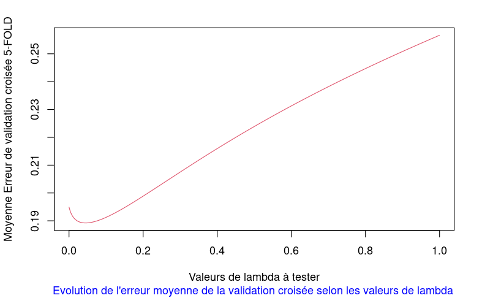

```r
plot(MFOLD,type="l",col=2,xlab="Valeurs de lambda à tester",ylab="Moyenne Erreur de validation croisée 5-FOLD",sub="Evolution de l'erreur moyenne de la validation croisée selon les valeurs de lambda ",col.sub="blue")
```

On remarque que pour une haute valeur de lambda, l’erreur augmente. La meilleur valeur qui minimise l’erreur est :

```r
Lambda_optF=MFOLD[which.min(MFOLD[,2]),1]
Lambda_optF
```

```
[1] 0.0446
```

```r
mf.ridge_Lambda_optF_trained =lmridge(price~.,train.data_tilte,K=Lambda_optF)
summary(mf.ridge_Lambda_optF_trained)
```

```
Call:
lmridge.default(formula = price ~ ., data = train.data_tilte,
    K = Lambda_optF)


Coefficients: for Ridge parameter K= 0.0446
                 Estimate Estimate (Sc) StdErr (Sc) t-value (Sc) Pr(>|t|)
Intercept          0.0000        0.0000      0.0814       0.0000   1.0000
wheelbase          0.0784        0.9607      0.8403       1.1432   0.2549
carlength         -0.0290       -0.3557      0.9091      -0.3912   0.6962
carwidth           0.1334        1.6336      0.7808       2.0922   0.0382 *
carheight          0.0093        0.1142      0.5948       0.1921   0.8480
curbweight         0.1094        1.3395      0.9765       1.3718   0.1723
enginesize         0.4302        5.2691      0.7978       6.6042   <2e-16 ***
boreratio         -0.0388       -0.4755      0.5791      -0.8211   0.4130
stroke            -0.1204       -1.4751      0.4708      -3.1332   0.0021 **
compressionratio   0.1413        1.7303      0.5648       3.0634   0.0026 **
horsepower         0.2537        3.1069      0.8327       3.7311   0.0003 ***
peakrpm            0.1495        1.8311      0.5524       3.3147   0.0012 **
citympg           -0.1351       -1.6551      0.8214      -2.0149   0.0458 *
highwaympg         0.0823        1.0085      0.8111       1.2434   0.2158
---
Signif. codes:  0 ‘***’ 0.001 ‘**’ 0.01 ‘*’ 0.05 ‘.’ 0.1 ‘ ’ 1

Ridge Summary
        R2     adj-R2   DF ridge          F        AIC        BIC
   0.77370    0.75400   10.29321   44.90441 -228.53303  560.13372
Ridge minimum MSE= 32.18669 at K= 0.0446
P-value for F-test ( 10.29321 , 139.1464 ) = 3.441883e-39
-------------------------------------------------------------------
```

```r
predictions_test_tilte = predict(mf.ridge_Lambda_optF_trained,test.data_tilte)
predictions_test = predictions_test_tilte*sd(test.data$price)+mean(test.data$price)
predictions_test
```

```
       14        25        29        34        35        38        42        47        48        49        51        53        60
15182.500  6462.946 10363.583  7977.003  8003.230 10287.352 11492.874 10562.490 29773.464 29773.464  4713.623  5364.366  9669.866
       64        69        70        74        77        80        81        83        87        95       100       104       107
11529.336 24183.298 23363.745 37333.243  5995.652  8860.369 11761.309 15434.774  9668.369  5773.690 10351.205 21960.962 23203.978
      108       112       113       118       119       121       122       125       129       131       133       136       140
14796.785 17682.430 17045.368 19983.447  5492.010  6462.946  6309.029 15397.127 27329.081 10630.732 14322.724 14483.626  6342.674
      144       150       156       157       172       176       177       187       189       192       199       204
11458.853 11111.671  6835.054  6240.590 13318.733  8500.932  8533.194  9560.384 11479.477 15864.741 18637.780 20752.925
```

```r
sum((test.data$price - predictions_test)^2)
```

```
[1] 415589630
```

## ⚙ (B) régularisation LASSO

### ◼ Load the Data

To perform lasso regression, we’ll use functions from the glmnet package. This package requires the response variable to be a vector and the set of predictor variables to be of the class data.matrix.

```r
y <- data_cars_tilte$price
x <- data.matrix( data_cars_tilte[,1:(ncol( data_cars_tilte)-1)])
```

```r
y_train <- train.data_tilte$price
length(y_train)
```

```
[1] 151
```

```r
y_test <- test.data_tilte$price
length(y_test)
```

```
[1] 51
```

```r
x_train = data.matrix( train.data_tilte[,1:(ncol( train.data_tilte)-1)])
dim(x_train)
```

```
[1] 151  13
```

```r
x_test = data.matrix( test.data_tilte[,1:(ncol(test.data_tilte)-1)])
dim(x_test)
```

```
[1] 51 13
```

### ◼ Ajuster le modèle de régression Lasso : quel est le lambda optimal ?

Next, we’ll use the glmnet() function to fit the lasso regression model and specify alpha=1.

Note that setting alpha equal to 0 is equivalent to using ridge regression and setting alpha to some value between 0 and 1 is equivalent to using an elastic net.

To determine what value to use for lambda, we’ll perform k-fold cross-validation and identify the lambda value that produces the lowest test mean squared error (MSE).

Note that the function cv.glmnet() automatically performs k-fold cross validation using k = 10 folds.

```r
#perform k-fold cross-validation to find optimal lambda value
cv_model <- cv.glmnet(x, y, alpha = 1,nfolds=5)

#find optimal lambda value that minimizes test MSE
best_lambda_lasso <- cv_model$lambda.min
best_lambda_lasso
```

```
[1] 0.00676722
```

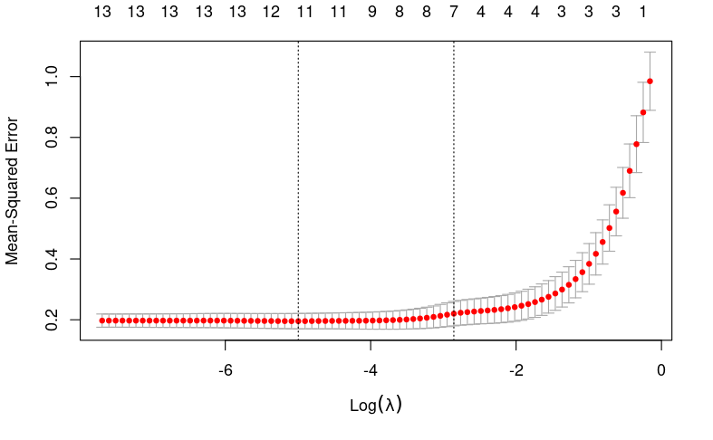

```r
#produce plot of test MSE by lambda value
plot(cv_model)
```

### ◼ Analyze Final Model

Lastly, we can analyze the final model produced by the optimal lambda value.

We can use the following code to obtain the coefficient estimates for this model:

```r
#find coefficients of best model
best_model_lasso <- glmnet(x, y, alpha = 1, lambda = best_lambda_lasso)
coef(best_model_lasso)
```

```
14 x 1 sparse Matrix of class "dgCMatrix"
                            s0
(Intercept)      -1.419535e-16
wheelbase         7.338501e-02
carlength         .
carwidth          8.427875e-02
carheight         4.660375e-03
curbweight        5.361745e-02
enginesize        5.520030e-01
boreratio        -4.076724e-02
stroke           -1.313976e-01
compressionratio  1.665602e-01
horsepower        2.529159e-01
peakrpm           1.360433e-01
citympg          -4.792755e-02
highwaympg        .
```

```r
summary(best_model_lasso)
```

```
          Length Class     Mode
a0         1     -none-    numeric
beta      13     dgCMatrix S4
df         1     -none-    numeric
dim        2     -none-    numeric
lambda     1     -none-    numeric
dev.ratio  1     -none-    numeric
nulldev    1     -none-    numeric
npasses    1     -none-    numeric
jerr       1     -none-    numeric
offset     1     -none-    logical
call       5     -none-    call
nobs       1     -none-    numeric
```

## BONus perso ◼ meilleur lambda RIDGE : glmnet

```r
#perform k-fold cross-validation to find optimal lambda value
cv_model <- cv.glmnet(x, y, alpha = 0,nfolds=5)

#find optimal lambda value that minimizes test MSE
best_lambda_ridge <- cv_model$lambda.min
best_lambda_ridge
```

```
[1] 0.08539263
```

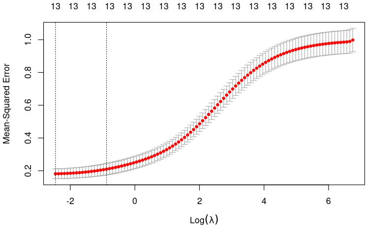

```r
#produce plot of test MSE by lambda value
plot(cv_model)
```

```r
#find coefficients of best model
best_model <- glmnet(x, y, alpha = 0, lambda = best_lambda_ridge)
coef(best_model)
```

```
14 x 1 sparse Matrix of class "dgCMatrix"
                            s0
(Intercept)      -1.621903e-16
wheelbase         7.138975e-02
carlength        -1.852719e-02
carwidth          9.819841e-02
carheight         6.023087e-03
curbweight        1.396830e-01
enginesize        4.285038e-01
boreratio        -3.304042e-02
stroke           -1.097622e-01
compressionratio  1.424407e-01
horsepower        2.646006e-01
peakrpm           1.133457e-01
citympg          -6.774080e-02
highwaympg        1.888125e-02
```

```r
mf.ridge_Lambda_optF_trained
```

```
Call:
lmridge.default(formula = price ~ ., data = train.data_tilte,
    K = Lambda_optF)

       Intercept        wheelbase        carlength         carwidth        carheight       curbweight       enginesize
         0.00000          0.07844         -0.02904          0.13338          0.00933          0.10937          0.43022
       boreratio           stroke compressionratio       horsepower          peakrpm          citympg       highwaympg
        -0.03883         -0.12044          0.14128          0.25368          0.14951         -0.13514          0.08234
```